# Predicting Breast Cancer Malignancy

Xinyu Xie, Jackie Yang, Xu Hao

May 9, 2025

```r
rm(list = ls())
library(tidyverse)
library(kableExtra)
library(caret)
library(glmnet)
library(pROC)
library(randomForest)
library(class)
library(factoextra)
library(lme4)
Cancer_Data <- read.csv("C:/ESSENTIALS/School OS/Junior Spring 2025/STAT 400/Final Project/Cancer_Data.csv")
#Cancer_Data <- read.csv("Cancer_Data.csv")
```

## Dataset Overview

**Research Question** Can a derived tumor volume feature lead to a simpler and more interpretable generalized linear model (GLM) for predicting tumor malignancy?

**Main features**

`id`: Represents a unique ID of each patient

`diagnosis`: Indicates the type of cancer. “M” represents malignant, and “B” represents benign.

`radius_mean`: mean of distances from center to points on the perimeter

`texture_mean`: standard deviation of gray-scale values

`area_mean`: Mean area of the cell nuclei (measured in pixels)

`perimeter_mean`: mean size of core tumor

`smoothness_mean`: mean of local variation in radius lengths

`compactness_mean`: mean of $\frac{\text{Perimeter}^2}{\text{Area} - 1.0}$

`concavity_mean`: mean of severity of concave portions of the contour

`concave points_mean`: mean for number of concave portions of the contour, represents the mean values of the cancer’s visual characteristics

Response Variable ‘diagnosis’ is a categorical variable with 2 levels (“M” for malignant and “B” for benign). All other predictor variables are quantitative, capturing various characteristics of cell nuclei.

**Resources**

- Dataset: [Kaggle – Cancer Data](https://www.kaggle.com/datasets/erdemtaha/cancer-data)
- Reference: [Volume-Diameter Article on JCPSP](https://jcpsp.pk/article-detail/comparison-of-tumor-volume-dependent-mean-diameter-with-the-longest-diameter-and-tumor-volume-in-assessing-axillary-lymph-nodes-in-breast-cancer)

## Table Preview: Selected Predictors for Diagnosis Modeling

```r
Cancer_Data %>%
  select(diagnosis, radius_mean, texture_mean, area_mean,
         smoothness_mean, compactness_mean, concavity_mean, concave.points_mean) %>%
  head(5) %>%
  kable(caption = "First 5 Rows of Key Variables Used in Modeling") %>%
  kable_styling(bootstrap_options = c("striped", "hover", "condensed", "bordered"))
```

First 5 Rows of Key Variables Used in Modeling

| diagnosis | radius_mean | texture_mean | area_mean | smoothness_mean | compactness_mean | concavity_mean | concave.points_mean |
| --- | --- | --- | --- | --- | --- | --- | --- |
| M | 17.99 | 10.38 | 1001.0 | 0.11840 | 0.27760 | 0.3001 | 0.14710 |
| M | 20.57 | 17.77 | 1326.0 | 0.08474 | 0.07864 | 0.0869 | 0.07017 |
| M | 19.69 | 21.25 | 1203.0 | 0.10960 | 0.15990 | 0.1974 | 0.12790 |
| M | 11.42 | 20.38 | 386.1 | 0.14250 | 0.28390 | 0.2414 | 0.10520 |
| M | 20.29 | 14.34 | 1297.0 | 0.10030 | 0.13280 | 0.1980 | 0.10430 |

## Data Preparation

```r
#Clean and transform dataset
Cancer_Data <- Cancer_Data %>%
  dplyr::select(-id, -X) %>%
  na.omit() %>%
  mutate(
    tumor_volume = ((pi / 6) * radius_mean *
                    (perimeter_mean / (2 * pi)) *
                    sqrt(area_mean / pi)),
    diagnosis_bin = ifelse(diagnosis == "M", 1, 0)
  )

#Standardize selected predictors
xvars <- c(
  "radius_mean", "texture_mean", "perimeter_mean", "area_mean", "smoothness_mean",
  "compactness_mean", "concavity_mean", "concave.points_mean", "symmetry_mean", "fractal_dimension_mean",
  "radius_se", "texture_se", "perimeter_se", "area_se", "smoothness_se",
  "compactness_se", "concavity_se", "concave.points_se", "symmetry_se", "fractal_dimension_se",
  "radius_worst", "texture_worst", "perimeter_worst", "area_worst", "smoothness_worst",
  "compactness_worst", "concavity_worst", "concave.points_worst", "symmetry_worst", "fractal_dimension_worst",
  "tumor_volume"
)
Cancer_Data[, xvars] <- scale(Cancer_Data[, xvars], center = TRUE, scale = TRUE)

#Preview cleaned dataset
summary(Cancer_Data)
```

```
##   diagnosis          radius_mean       texture_mean     perimeter_mean
##  Length:569         Min.   :-2.0279   Min.   :-2.2273   Min.   :-1.9828
##  Class :character   1st Qu.:-0.6888   1st Qu.:-0.7253   1st Qu.:-0.6913
##  Mode  :character   Median :-0.2149   Median :-0.1045   Median :-0.2358
##                     Mean   : 0.0000   Mean   : 0.0000   Mean   : 0.0000
##                     3rd Qu.: 0.4690   3rd Qu.: 0.5837   3rd Qu.: 0.4992
##                     Max.   : 3.9678   Max.   : 4.6478   Max.   : 3.9726
##    area_mean       smoothness_mean    compactness_mean  concavity_mean
##  Min.   :-1.4532   Min.   :-3.10935   Min.   :-1.6087   Min.   :-1.1139
##  1st Qu.:-0.6666   1st Qu.:-0.71034   1st Qu.:-0.7464   1st Qu.:-0.7431
##  Median :-0.2949   Median :-0.03486   Median :-0.2217   Median :-0.3419
##  Mean   : 0.0000   Mean   : 0.00000   Mean   : 0.0000   Mean   : 0.0000
##  3rd Qu.: 0.3632   3rd Qu.: 0.63564   3rd Qu.: 0.4934   3rd Qu.: 0.5256
##  Max.   : 5.2459   Max.   : 4.76672   Max.   : 4.5644   Max.   : 4.2399
##  concave.points_mean symmetry_mean      fractal_dimension_mean
##  Min.   :-1.2607     Min.   :-2.74171   Min.   :-1.8183
##  1st Qu.:-0.7373     1st Qu.:-0.70262   1st Qu.:-0.7220
##  Median :-0.3974     Median :-0.07156   Median :-0.1781
##  Mean   : 0.0000     Mean   : 0.00000   Mean   : 0.0000
##  3rd Qu.: 0.6464     3rd Qu.: 0.53031   3rd Qu.: 0.4706
##  Max.   : 3.9245     Max.   : 4.48081   Max.   : 4.9066
##    radius_se         texture_se       perimeter_se        area_se
##  Min.   :-1.0590   Min.   :-1.5529   Min.   :-1.0431   Min.   :-0.7372
##  1st Qu.:-0.6230   1st Qu.:-0.6942   1st Qu.:-0.6232   1st Qu.:-0.4943
##  Median :-0.2920   Median :-0.1973   Median :-0.2864   Median :-0.3475
##  Mean   : 0.0000   Mean   : 0.0000   Mean   : 0.0000   Mean   : 0.0000
##  3rd Qu.: 0.2659   3rd Qu.: 0.4661   3rd Qu.: 0.2428   3rd Qu.: 0.1067
##  Max.   : 8.8991   Max.   : 6.6494   Max.   : 9.4537   Max.   :11.0321
##  smoothness_se     compactness_se     concavity_se     concave.points_se
##  Min.   :-1.7745   Min.   :-1.2970   Min.   :-1.0566   Min.   :-1.9118
##  1st Qu.:-0.6235   1st Qu.:-0.6923   1st Qu.:-0.5567   1st Qu.:-0.6739
##  Median :-0.2201   Median :-0.2808   Median :-0.1989   Median :-0.1404
##  Mean   : 0.0000   Mean   : 0.0000   Mean   : 0.0000   Mean   : 0.0000
##  3rd Qu.: 0.3680   3rd Qu.: 0.3893   3rd Qu.: 0.3365   3rd Qu.: 0.4722
##  Max.   : 8.0229   Max.   : 6.1381   Max.   :12.0621   Max.   : 6.6438
##   symmetry_se      fractal_dimension_se  radius_worst     texture_worst
##  Min.   :-1.5315   Min.   :-1.0960      Min.   :-1.7254   Min.   :-2.22204
##  1st Qu.:-0.6511   1st Qu.:-0.5846      1st Qu.:-0.6743   1st Qu.:-0.74797
##  Median :-0.2192   Median :-0.2297      Median :-0.2688   Median :-0.04348
##  Mean   : 0.0000   Mean   : 0.0000      Mean   : 0.0000   Mean   : 0.00000
```

[output cut: 8 more lines]

```
##  Max.   : 4.2836   Max.   : 5.9250   Max.   : 3.9519   Max.   : 5.1084
##  concavity_worst   concave.points_worst symmetry_worst
##  Min.   :-1.3047   Min.   :-1.7435      Min.   :-2.1591
##  1st Qu.:-0.7558   1st Qu.:-0.7557      1st Qu.:-0.6413
##  Median :-0.2180   Median :-0.2233      Median :-0.1273
##  Mean   : 0.0000   Mean   : 0.0000      Mean   : 0.0000
##  3rd Qu.: 0.5307   3rd Qu.: 0.7119      3rd Qu.: 0.4497
##  Max.   : 4.6965   Max.   : 2.6835      Max.   : 6.0407
##  fractal_dimension_worst  tumor_volume     diagnosis_bin
##  Min.   :-1.6004         Min.   :-1.0284   Min.   :0.0000
##  1st Qu.:-0.6913         1st Qu.:-0.6116   1st Qu.:0.0000
##  Median :-0.2163         Median :-0.3476   Median :0.0000
##  Mean   : 0.0000         Mean   : 0.0000   Mean   :0.3726
##  3rd Qu.: 0.4504         3rd Qu.: 0.2163   3rd Qu.:1.0000
##  Max.   : 6.8408         Max.   : 6.5671   Max.   :1.0000
```

### Planned Modeling Formula

Based on our exploratory analysis, we plan to fit the following logistic regression model:

$$diagnosis_{bin} \sim
concave.points_{worst} + tumor_{volume} + texture_{worst} +
smoothness_{worst}$$

## Exploratory Plots for Key Predictors

The following boxplots illustrate the distribution of selected predictors stratified by tumor diagnosis. These visualizations support the relevance of each variable in distinguishing malignant from benign tumors.

### Radius Mean by Diagnosis

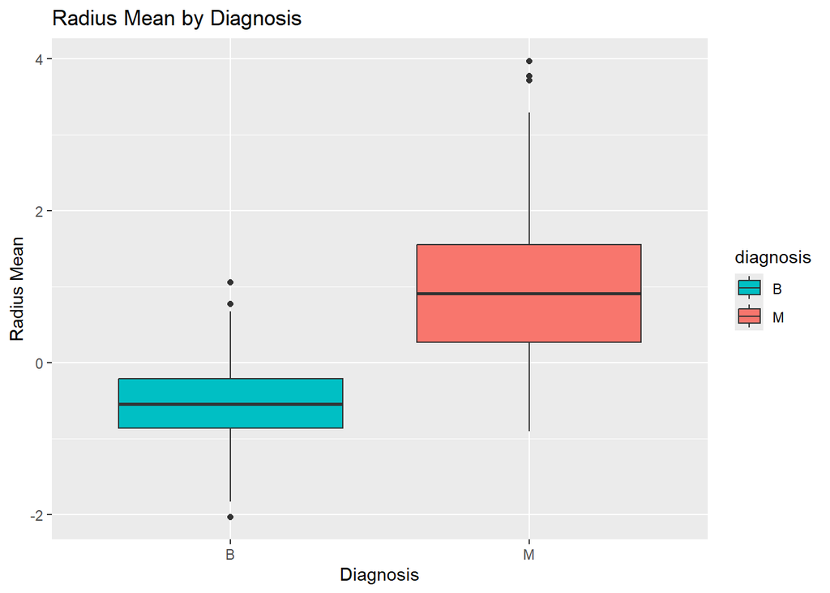

```r
#Colorpalette
diagnosis_colors <- c("B" = "#00BFC4", "M" = "#F8766D")

ggplot(Cancer_Data, aes(x = diagnosis, y = radius_mean, fill = diagnosis)) +
  geom_boxplot() +
  scale_fill_manual(values = diagnosis_colors) +
  labs(title = "Radius Mean by Diagnosis", x = "Diagnosis", y = "Radius Mean")
```

Malignant tumors show significantly higher radius_mean values (median = 0.91) than benign ones (median = -0.55). This indicates that tumor size—specifically the distance from center to edge—is a strong differentiator between classes, and radius_mean serves as a critical feature in model construction.

### Perimeter Mean by Diagnosis

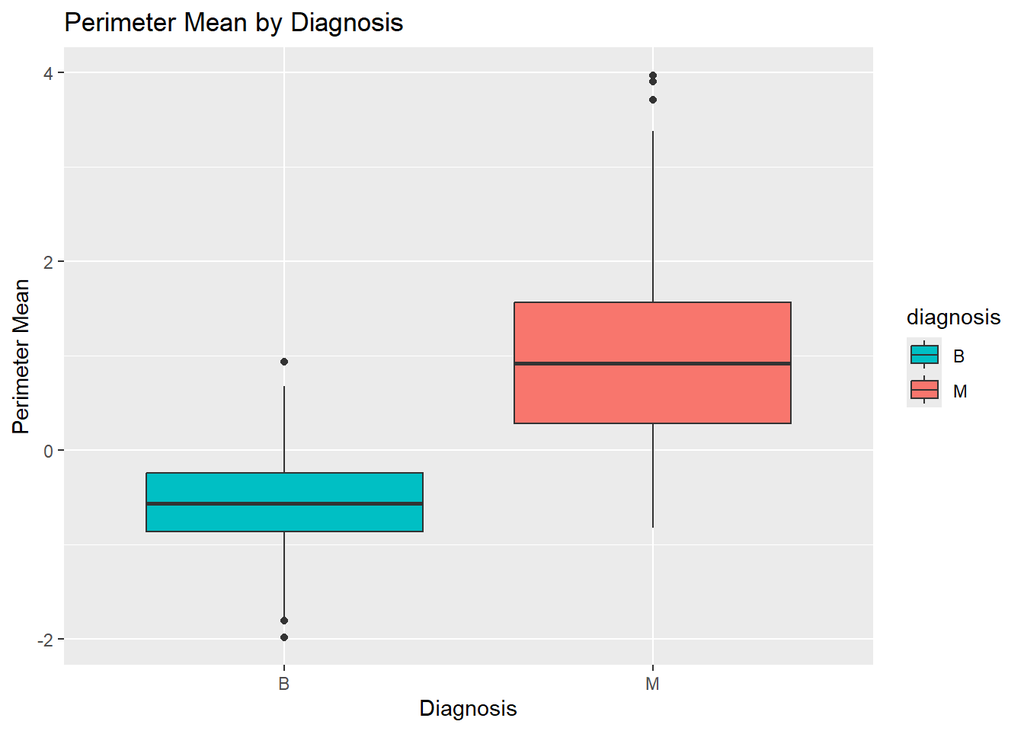

```r
ggplot(Cancer_Data, aes(x = diagnosis, y = perimeter_mean, fill = diagnosis)) +
  geom_boxplot() +
  scale_fill_manual(values = diagnosis_colors) +
  labs(title = "Perimeter Mean by Diagnosis", x = "Diagnosis", y = "Perimeter Mean")
```

With median standardized values of 0.92 (malignant) and -0.57 (benign), perimeter_mean provides strong separation across diagnosis groups. This aligns with the biological interpretation that malignant tumors tend to exhibit more irregular and extended boundaries.

### Area Mean by Diagnosis

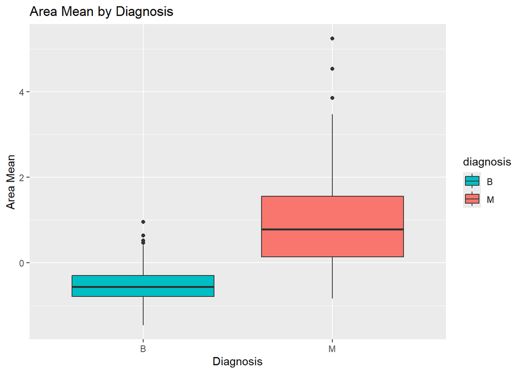

```r
ggplot(Cancer_Data, aes(x = diagnosis, y = area_mean, fill = diagnosis)) +
  geom_boxplot() +
  scale_fill_manual(values = diagnosis_colors) +
  labs(title = "Area Mean by Diagnosis", x = "Diagnosis", y = "Area Mean")
```

Area_mean is another high-separation variable, with medians of 0.79 (malignant) vs. -0.56 (benign). This confirms that overall tumor size plays a major role in classification and supports including this feature in both GLM and Random Forest models.

### Concave Points Worst by Diagnosis

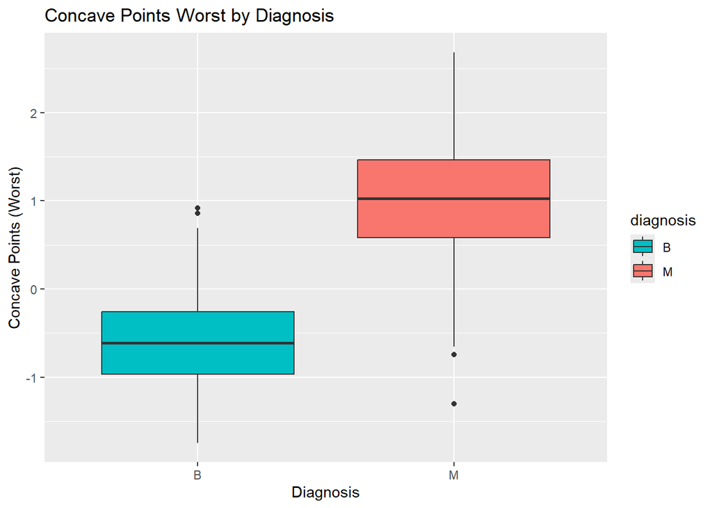

```r
ggplot(Cancer_Data, aes(x = diagnosis, y = concave.points_worst, fill = diagnosis)) +
  geom_boxplot() +
  scale_fill_manual(values = diagnosis_colors) +
  labs(title = "Concave Points Worst by Diagnosis", x = "Diagnosis", y = "Concave Points (Worst)")
```

Concave points (worst) provides the strongest contrast of all features (median = 1.03 for malignant vs. -0.61 for benign), indicating more severe contour indentations in malignant tumors. Its discriminative power suggests it could dominate variable importance rankings.

### Tumor Volume by Diagnosis

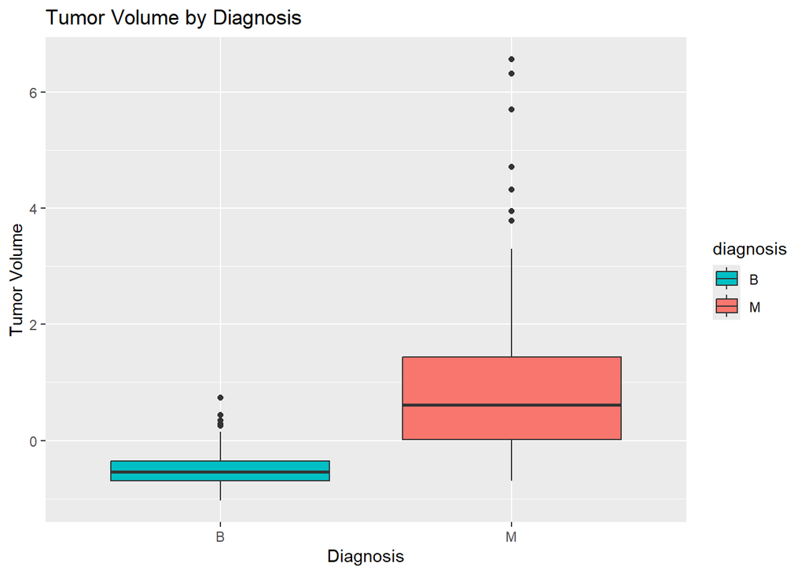

```r
ggplot(Cancer_Data, aes(x = diagnosis, y = tumor_volume, fill = diagnosis)) +
  geom_boxplot() +
  scale_fill_manual(values = diagnosis_colors) +
  labs(title = "Tumor Volume by Diagnosis", x = "Diagnosis", y = "Tumor Volume")
```

The derived tumor_volume feature—based on radius, perimeter, and area—shows a clean class split: 0.61 for malignant vs. -0.54 for benign. This validates our domain-informed feature engineering step and demonstrates that volume integrates multiple shape signals effectively.

### Texture Worst by Diagnosis

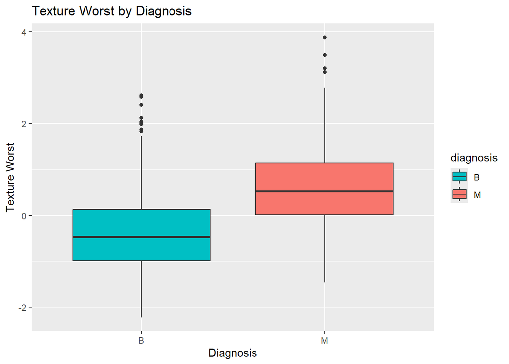

```r
ggplot(Cancer_Data, aes(x = diagnosis, y = texture_worst, fill = diagnosis)) +
  geom_boxplot() +
  scale_fill_manual(values = diagnosis_colors) +
  labs(title = "Texture Worst by Diagnosis", x = "Diagnosis", y = "Texture Worst")
```

Although less extreme than structural metrics, texture_worst still displays a meaningful shift (0.53 malignant vs. -0.47 benign). Its relevance may lie in capturing the heterogeneity of cell nucleus surfaces, supporting its inclusion in models prioritizing subtle distinctions.

### Smoothness Worst by Diagnosis

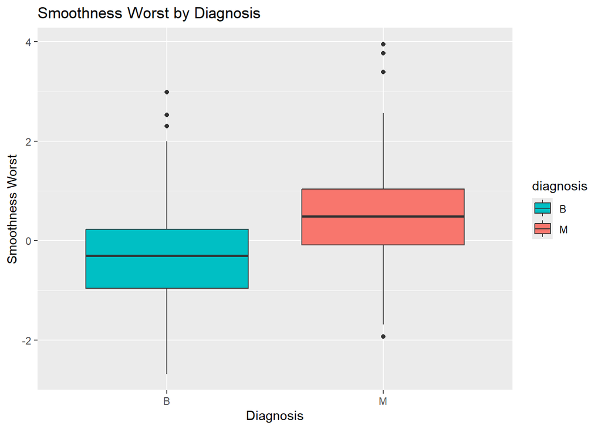

```r
ggplot(Cancer_Data, aes(x = diagnosis, y = smoothness_worst, fill = diagnosis)) +
  geom_boxplot() +
  scale_fill_manual(values = diagnosis_colors) +
  labs(title = "Smoothness Worst by Diagnosis", x = "Diagnosis", y = "Smoothness Worst")
```

Smoothness worst exhibits the smallest—but still present—class-based median shift (0.49 malignant vs. -0.31 benign). While its predictive power may be secondary, its potential contribution to ensemble or regularized models remains valuable.

## Model Development: Training and Validation Split

To evaluate model generalizability, we partitioned the dataset into an 80% training set and a 20% validation set. The random seed was fixed to ensure reproducibility of results.

```r
#Fix the random seed for reproducibility
set.seed(123)
n <- nrow(Cancer_Data)

#Randomly select 80% of the data to use as training set
index <- sample(1:n, size = 0.8 * n)

#Create 80/20 training and validation sets
Cancer_Data_train <- Cancer_Data[index, ]
validation_data <- Cancer_Data[-index, ]
```

# Logistic Regression Model (GLM)

## Stepwise Logistic Model (All Predictors Included)

```r
#Define predictor set
predictors <- setdiff(names(Cancer_Data_train), c("id", "diagnosis", "diagnosis_bin", "predicted_prob","Hospital", "tumor_volume"))

#Create full and null formulas
full_formula <- as.formula(paste("diagnosis_bin ~", paste(predictors, collapse = " + ")))
full_model <- glm(full_formula, data = Cancer_Data_train, family = binomial)
null_model <- glm(diagnosis_bin ~ 1, data = Cancer_Data_train, family = binomial)

#Stepwise selection using AIC & BIC
step_aic <- step(null_model,
                 scope = list(lower = null_model, upper = full_model),
                 direction = "both",
                 trace = TRUE)

step_bic <- step(null_model,
                 scope = list(lower = null_model, upper = full_model),
                 direction = "both",
                 k = log(n),
                 trace = TRUE)
```

## Stepwise Logistic Model (Excluding Tumor Volume Predictors)

```r
#Define predictor set
predictors <- setdiff(names(Cancer_Data_train), c("id", "diagnosis", "diagnosis_bin", "predicted_prob","Hospital",
  "radius_mean", "perimeter_mean", "area_mean",
  "radius_se", "perimeter_se", "area_se",
  "radius_worst", "perimeter_worst", "area_worst"))

#Create full and null formulas
full_formula_notumor <- as.formula(paste("diagnosis_bin ~", paste(predictors, collapse = " + ")))
full_model_notumorralate <- glm(full_formula_notumor, data = Cancer_Data_train, family = binomial)
null_model_notumorralate <- glm(diagnosis_bin ~ 1, data = Cancer_Data_train, family = binomial)

#Stepwise selection using AIC & BIC
step_aic_notumorralate <- step(null_model_notumorralate,
                 scope = list(lower = null_model_notumorralate, upper = full_model_notumorralate),
                 direction = "both",
                 trace = TRUE)
```

```
## Start:  AIC=590.87
## diagnosis_bin ~ 1
```

```
##                           Df Deviance    AIC
## + concave.points_worst     1   206.00 210.00
## + concave.points_mean      1   208.98 212.98
## + tumor_volume             1   255.30 259.30
## + concavity_mean           1   319.00 323.00
## + concavity_worst          1   357.49 361.49
## + compactness_worst        1   406.24 410.24
## + compactness_mean         1   414.25 418.25
## + texture_worst            1   481.14 485.14
## + texture_mean             1   499.79 503.79
## + symmetry_worst           1   507.62 511.62
## + smoothness_worst         1   513.51 517.51
## + concave.points_se        1   517.46 521.46
## + smoothness_mean          1   536.54 540.54
## + fractal_dimension_worst  1   546.51 550.51
## + symmetry_mean            1   547.83 551.83
## + compactness_se           1   557.58 561.58
## + concavity_se             1   565.51 569.51
## <none>                         588.87 590.87
## + smoothness_se            1   587.18 591.18
## + fractal_dimension_se     1   587.32 591.32
## + fractal_dimension_mean   1   587.80 591.80
## + texture_se               1   588.53 592.53
## + symmetry_se              1   588.83 592.83
##
## Step:  AIC=210
## diagnosis_bin ~ concave.points_worst
```

```
##                           Df Deviance    AIC
## + tumor_volume             1   142.25 148.25
## + texture_mean             1   164.67 170.67
## + texture_worst            1   172.17 178.17
## + fractal_dimension_mean   1   173.31 179.31
## + concave.points_mean      1   185.25 191.25
## + fractal_dimension_worst  1   190.53 196.53
## + fractal_dimension_se     1   195.13 201.13
## + compactness_mean         1   196.76 202.76
## + concavity_se             1   196.80 202.80
## + compactness_se           1   197.27 203.27
## + compactness_worst        1   198.44 204.44
## + concave.points_se        1   201.43 207.43
## + texture_se               1   201.79 207.79
## + concavity_worst          1   202.08 208.08
## + smoothness_mean          1   203.71 209.71
## <none>                         206.00 210.00
## + smoothness_worst         1   204.80 210.80
## + symmetry_worst           1   205.00 211.00
## + symmetry_mean            1   205.59 211.59
## + symmetry_se              1   205.87 211.87
## + concavity_mean           1   206.00 212.00
## + smoothness_se            1   206.00 212.00
## - concave.points_worst     1   588.87 590.87
```

```
##
## Step:  AIC=148.25
## diagnosis_bin ~ concave.points_worst + tumor_volume
```

```
##                           Df Deviance    AIC
## + texture_worst            1   102.24 110.24
## + texture_mean             1   110.24 118.24
## + smoothness_worst         1   131.41 139.41
## + texture_se               1   131.94 139.94
## + symmetry_worst           1   133.47 141.47
## + smoothness_mean          1   140.05 148.05
## + compactness_mean         1   140.12 148.12
## + compactness_se           1   140.16 148.16
## <none>                         142.25 148.25
## + concave.points_se        1   140.51 148.51
## + fractal_dimension_se     1   140.57 148.57
## + concavity_se             1   140.61 148.61
## + fractal_dimension_worst  1   140.63 148.63
## + symmetry_mean            1   140.81 148.81
## + smoothness_se            1   141.35 149.35
## + concave.points_mean      1   141.61 149.61
## + concavity_worst          1   141.62 149.62
## + symmetry_se              1   141.94 149.94
## + fractal_dimension_mean   1   142.07 150.07
## + compactness_worst        1   142.13 150.13
## + concavity_mean           1   142.23 150.23
## - tumor_volume             1   206.00 210.00
## - concave.points_worst     1   255.30 259.30
```

```
##
## Step:  AIC=110.24
## diagnosis_bin ~ concave.points_worst + tumor_volume + texture_worst
```

```
##                           Df Deviance    AIC
## + smoothness_worst         1   95.742 105.74
## + smoothness_mean          1   96.093 106.09
## + symmetry_worst           1   96.819 106.82
## + concave.points_mean      1   98.860 108.86
## + symmetry_mean            1   99.537 109.54
## + compactness_se           1   99.897 109.90
## <none>                        102.239 110.24
## + fractal_dimension_se     1  101.094 111.09
## + symmetry_se              1  101.264 111.26
## + compactness_mean         1  101.467 111.47
## + smoothness_se            1  101.556 111.56
## + fractal_dimension_worst  1  101.635 111.64
## + concavity_se             1  101.736 111.74
## + concavity_worst          1  101.756 111.76
## + concavity_mean           1  101.918 111.92
## + concave.points_se        1  102.049 112.05
## + compactness_worst        1  102.089 112.09
## + fractal_dimension_mean   1  102.154 112.15
## + texture_mean             1  102.225 112.22
## + texture_se               1  102.226 112.23
## - texture_worst            1  142.248 148.25
## - tumor_volume             1  172.166 178.17
## - concave.points_worst     1  199.210 205.21
```

```
##
## Step:  AIC=105.74
## diagnosis_bin ~ concave.points_worst + tumor_volume + texture_worst +
##     smoothness_worst
```

```
##                           Df Deviance    AIC
## + symmetry_worst           1   90.931 102.93
## <none>                         95.742 105.74
## + symmetry_se              1   93.820 105.82
## + symmetry_mean            1   93.833 105.83
## + concave.points_mean      1   93.947 105.95
## + compactness_mean         1   94.423 106.42
## + compactness_se           1   94.495 106.50
## + concavity_worst          1   94.548 106.55
## + fractal_dimension_se     1   94.776 106.78
## + concavity_mean           1   94.790 106.79
## + smoothness_mean          1   95.104 107.10
## + smoothness_se            1   95.594 107.59
## + compactness_worst        1   95.634 107.63
## + fractal_dimension_worst  1   95.655 107.66
## + fractal_dimension_mean   1   95.676 107.68
## + texture_mean             1   95.696 107.70
## + concave.points_se        1   95.730 107.73
## + texture_se               1   95.737 107.74
## + concavity_se             1   95.742 107.74
## - smoothness_worst         1  102.239 110.24
## - concave.points_worst     1  114.515 122.52
## - texture_worst            1  131.414 139.41
## - tumor_volume             1  168.660 176.66
```

```
##
## Step:  AIC=102.93
## diagnosis_bin ~ concave.points_worst + tumor_volume + texture_worst +
##     smoothness_worst + symmetry_worst
```

```
##                           Df Deviance    AIC
## + concave.points_mean      1   88.396 102.40
## <none>                         90.931 102.93
## + compactness_mean         1   88.944 102.94
## + compactness_worst        1   89.045 103.05
## + compactness_se           1   89.800 103.80
## + concavity_mean           1   90.045 104.05
## + fractal_dimension_se     1   90.139 104.14
## + smoothness_mean          1   90.201 104.20
## + fractal_dimension_mean   1   90.403 104.40
## + concave.points_se        1   90.431 104.43
## + concavity_worst          1   90.566 104.57
## + fractal_dimension_worst  1   90.647 104.65
## + texture_mean             1   90.682 104.68
## + texture_se               1   90.721 104.72
## + symmetry_se              1   90.823 104.82
## + smoothness_se            1   90.850 104.85
## + concavity_se             1   90.910 104.91
## + symmetry_mean            1   90.930 104.93
## - symmetry_worst           1   95.742 105.74
## - smoothness_worst         1   96.819 106.82
## - concave.points_worst     1  100.692 110.69
## - texture_worst            1  124.537 134.54
## - tumor_volume             1  167.944 177.94
```

```
##
## Step:  AIC=102.4
## diagnosis_bin ~ concave.points_worst + tumor_volume + texture_worst +
##     smoothness_worst + symmetry_worst + concave.points_mean
```

```
##                           Df Deviance     AIC
## + compactness_mean         1   78.733  94.733
## + compactness_se           1   84.451 100.451
## + fractal_dimension_se     1   85.619 101.619
## + fractal_dimension_mean   1   85.663 101.663
## + compactness_worst        1   85.774 101.774
## <none>                         88.396 102.396
## - concave.points_worst     1   90.725 102.725
## - concave.points_mean      1   90.931 102.931
## + symmetry_se              1   87.730 103.730
## + fractal_dimension_worst  1   87.910 103.910
## + symmetry_mean            1   88.108 104.108
## - smoothness_worst         1   92.125 104.125
## + concavity_se             1   88.166 104.166
## + concavity_worst          1   88.232 104.232
## + smoothness_se            1   88.253 104.253
## + texture_se               1   88.314 104.314
## + smoothness_mean          1   88.315 104.315
## + texture_mean             1   88.349 104.349
## + concavity_mean           1   88.375 104.375
## + concave.points_se        1   88.386 104.386
## - symmetry_worst           1   93.947 105.947
## - texture_worst            1  124.429 136.429
## - tumor_volume             1  130.111 142.111
```

```
##
## Step:  AIC=94.73
## diagnosis_bin ~ concave.points_worst + tumor_volume + texture_worst +
##     smoothness_worst + symmetry_worst + concave.points_mean +
##     compactness_mean
```

```
##                           Df Deviance     AIC
## + fractal_dimension_worst  1   76.000  94.000
## <none>                         78.733  94.733
## + symmetry_se              1   77.030  95.030
## + concavity_worst          1   77.186  95.186
## + texture_mean             1   77.521  95.521
## + compactness_worst        1   77.529  95.529
## + fractal_dimension_mean   1   77.782  95.782
## - concave.points_worst     1   81.924  95.924
## - smoothness_worst         1   82.119  96.119
## + concavity_mean           1   78.241  96.241
## + smoothness_mean          1   78.541  96.541
## + concave.points_se        1   78.587  96.587
## + compactness_se           1   78.640  96.640
## + concavity_se             1   78.706  96.706
## + smoothness_se            1   78.717  96.717
## + fractal_dimension_se     1   78.725  96.725
## + symmetry_mean            1   78.732  96.732
## + texture_se               1   78.733  96.733
## - symmetry_worst           1   88.089 102.089
## - compactness_mean         1   88.396 102.396
## - concave.points_mean      1   88.944 102.944
## - tumor_volume             1   98.075 112.075
## - texture_worst            1  115.245 129.245
```

```
##
## Step:  AIC=94
## diagnosis_bin ~ concave.points_worst + tumor_volume + texture_worst +
##     smoothness_worst + symmetry_worst + concave.points_mean +
##     compactness_mean + fractal_dimension_worst
```

```
##                           Df Deviance     AIC
## - concave.points_worst     1   77.437  93.437
## - smoothness_worst         1   77.768  93.768
## <none>                         76.000  94.000
## - fractal_dimension_worst  1   78.733  94.733
## + texture_mean             1   74.741  94.741
## + fractal_dimension_se     1   75.090  95.090
## + symmetry_se              1   75.106  95.106
## + concavity_worst          1   75.294  95.294
## + smoothness_mean          1   75.655  95.655
## + compactness_se           1   75.679  95.679
## + concave.points_se        1   75.826  95.826
## + compactness_worst        1   75.875  95.875
## + concavity_mean           1   75.892  95.892
## + fractal_dimension_mean   1   75.935  95.935
## + texture_se               1   75.972  95.972
## + concavity_se             1   75.983  95.983
## + symmetry_mean            1   75.988  95.988
## + smoothness_se            1   75.999  95.999
## - symmetry_worst           1   81.850  97.850
## - compactness_mean         1   87.910 103.910
## - concave.points_mean      1   88.916 104.916
## - tumor_volume             1   97.889 113.889
## - texture_worst            1  109.924 125.924
```

```
##
## Step:  AIC=93.44
## diagnosis_bin ~ tumor_volume + texture_worst + smoothness_worst +
##     symmetry_worst + concave.points_mean + compactness_mean +
##     fractal_dimension_worst
```

```
##                           Df Deviance     AIC
## <none>                         77.437  93.437
## + fractal_dimension_se     1   75.716  93.716
## + symmetry_se              1   75.768  93.768
## + concavity_worst          1   75.939  93.939
## + concave.points_worst     1   76.000  94.000
## + texture_mean             1   76.530  94.530
## + compactness_worst        1   76.700  94.700
## + fractal_dimension_mean   1   76.800  94.800
## + compactness_se           1   76.816  94.816
## + concave.points_se        1   77.184  95.184
## + smoothness_se            1   77.188  95.188
## - smoothness_worst         1   81.244  95.244
## + concavity_mean           1   77.285  95.285
## + texture_se               1   77.345  95.345
## + concavity_se             1   77.412  95.412
## + symmetry_mean            1   77.420  95.420
## + smoothness_mean          1   77.434  95.434
## - fractal_dimension_worst  1   81.924  95.924
## - symmetry_worst           1   85.137  99.137
## - compactness_mean         1   90.679 104.679
## - concave.points_mean      1  100.142 114.142
## - tumor_volume             1  106.733 120.733
## - texture_worst            1  112.578 126.578
```

```r
step_bic_notumorralate <- step(null_model_notumorralate,
                 scope = list(lower = null_model_notumorralate, upper = full_model_notumorralate),
                 direction = "both",
                 k = log(n),
                 trace = TRUE)
```

```
## Start:  AIC=595.21
## diagnosis_bin ~ 1
```

```
##                           Df Deviance    AIC
## + concave.points_worst     1   206.00 218.69
## + concave.points_mean      1   208.98 221.67
## + tumor_volume             1   255.30 267.99
## + concavity_mean           1   319.00 331.69
## + concavity_worst          1   357.49 370.17
## + compactness_worst        1   406.24 418.92
## + compactness_mean         1   414.25 426.94
## + texture_worst            1   481.14 493.82
## + texture_mean             1   499.79 512.48
## + symmetry_worst           1   507.62 520.31
## + smoothness_worst         1   513.51 526.20
## + concave.points_se        1   517.46 530.15
## + smoothness_mean          1   536.54 549.23
## + fractal_dimension_worst  1   546.51 559.19
## + symmetry_mean            1   547.83 560.52
## + compactness_se           1   557.58 570.26
## + concavity_se             1   565.51 578.19
## <none>                         588.87 595.21
## + smoothness_se            1   587.18 599.87
## + fractal_dimension_se     1   587.32 600.01
## + fractal_dimension_mean   1   587.80 600.49
## + texture_se               1   588.53 601.21
## + symmetry_se              1   588.83 601.51
##
## Step:  AIC=218.69
## diagnosis_bin ~ concave.points_worst
```

```
##                           Df Deviance    AIC
## + tumor_volume             1   142.25 161.28
## + texture_mean             1   164.67 183.71
## + texture_worst            1   172.17 191.20
## + fractal_dimension_mean   1   173.31 192.35
## + concave.points_mean      1   185.25 204.28
## + fractal_dimension_worst  1   190.53 209.56
## + fractal_dimension_se     1   195.13 214.16
## + compactness_mean         1   196.76 215.79
## + concavity_se             1   196.80 215.83
## + compactness_se           1   197.27 216.30
## + compactness_worst        1   198.44 217.47
## <none>                         206.00 218.69
## + concave.points_se        1   201.43 220.46
## + texture_se               1   201.79 220.82
## + concavity_worst          1   202.08 221.11
## + smoothness_mean          1   203.71 222.74
## + smoothness_worst         1   204.80 223.83
## + symmetry_worst           1   205.00 224.03
## + symmetry_mean            1   205.59 224.62
## + symmetry_se              1   205.87 224.90
## + concavity_mean           1   206.00 225.03
## + smoothness_se            1   206.00 225.03
## - concave.points_worst     1   588.87 595.21
```

```
##
## Step:  AIC=161.28
## diagnosis_bin ~ concave.points_worst + tumor_volume
```

```
##                           Df Deviance    AIC
## + texture_worst            1   102.24 127.61
## + texture_mean             1   110.24 135.62
## + smoothness_worst         1   131.41 156.79
## + texture_se               1   131.94 157.32
## + symmetry_worst           1   133.47 158.85
## <none>                         142.25 161.28
## + smoothness_mean          1   140.05 165.43
## + compactness_mean         1   140.12 165.50
## + compactness_se           1   140.16 165.53
## + concave.points_se        1   140.51 165.88
## + fractal_dimension_se     1   140.57 165.95
## + concavity_se             1   140.61 165.99
## + fractal_dimension_worst  1   140.63 166.00
## + symmetry_mean            1   140.81 166.18
## + smoothness_se            1   141.35 166.73
## + concave.points_mean      1   141.61 166.98
## + concavity_worst          1   141.62 167.00
## + symmetry_se              1   141.94 167.32
## + fractal_dimension_mean   1   142.07 167.45
## + compactness_worst        1   142.13 167.51
## + concavity_mean           1   142.23 167.60
## - tumor_volume             1   206.00 218.69
## - concave.points_worst     1   255.30 267.99
```

```
##
## Step:  AIC=127.61
## diagnosis_bin ~ concave.points_worst + tumor_volume + texture_worst
```

```
##                           Df Deviance    AIC
## + smoothness_worst         1   95.742 127.46
## <none>                        102.239 127.61
## + smoothness_mean          1   96.093 127.81
## + symmetry_worst           1   96.819 128.54
## + concave.points_mean      1   98.860 130.58
## + symmetry_mean            1   99.537 131.26
## + compactness_se           1   99.897 131.62
## + fractal_dimension_se     1  101.094 132.81
## + symmetry_se              1  101.264 132.98
## + compactness_mean         1  101.467 133.19
## + smoothness_se            1  101.556 133.28
## + fractal_dimension_worst  1  101.635 133.35
## + concavity_se             1  101.736 133.46
## + concavity_worst          1  101.756 133.47
## + concavity_mean           1  101.918 133.64
## + concave.points_se        1  102.049 133.77
## + compactness_worst        1  102.089 133.81
## + fractal_dimension_mean   1  102.154 133.87
## + texture_mean             1  102.225 133.94
## + texture_se               1  102.226 133.95
## - texture_worst            1  142.248 161.28
## - tumor_volume             1  172.166 191.20
## - concave.points_worst     1  199.210 218.24
```

```
##
## Step:  AIC=127.46
## diagnosis_bin ~ concave.points_worst + tumor_volume + texture_worst +
##     smoothness_worst
```

```
##                           Df Deviance    AIC
## <none>                         95.742 127.46
## - smoothness_worst         1  102.239 127.61
## + symmetry_worst           1   90.931 128.99
## + symmetry_se              1   93.820 131.88
## + symmetry_mean            1   93.833 131.90
## + concave.points_mean      1   93.947 132.01
## + compactness_mean         1   94.423 132.49
## + compactness_se           1   94.495 132.56
## + concavity_worst          1   94.548 132.61
## + fractal_dimension_se     1   94.776 132.84
## + concavity_mean           1   94.790 132.85
## + smoothness_mean          1   95.104 133.17
## + smoothness_se            1   95.594 133.66
## + compactness_worst        1   95.634 133.70
## + fractal_dimension_worst  1   95.655 133.72
## + fractal_dimension_mean   1   95.676 133.74
## + texture_mean             1   95.696 133.76
## + concave.points_se        1   95.730 133.79
## + texture_se               1   95.737 133.80
## + concavity_se             1   95.742 133.81
## - concave.points_worst     1  114.515 139.89
## - texture_worst            1  131.414 156.79
## - tumor_volume             1  168.660 194.04
```

## Model selection

```r
#AIC-selected model
summary(step_aic)
```

```
##
## Call:
## glm(formula = diagnosis_bin ~ perimeter_worst + smoothness_worst +
##     texture_worst + radius_se + compactness_mean + symmetry_worst +
##     concave.points_mean + texture_se + concavity_worst + compactness_se,
##     family = binomial, data = Cancer_Data_train)
##
## Coefficients:
##                     Estimate Std. Error z value Pr(>|z|)
## (Intercept)           0.3121     0.5562   0.561 0.574638
## perimeter_worst       5.4696     1.6349   3.346 0.000821 ***
## smoothness_worst      1.5282     0.7474   2.045 0.040879 *
## texture_worst         3.0182     0.8434   3.578 0.000346 ***
## radius_se             4.5791     1.5957   2.870 0.004109 **
## compactness_mean     -3.2597     1.5501  -2.103 0.035480 *
## symmetry_worst        0.9362     0.4626   2.024 0.042963 *
## concave.points_mean   5.1271     1.8720   2.739 0.006165 **
## texture_se           -1.2200     0.7832  -1.558 0.119295
## concavity_worst       2.2472     0.8374   2.684 0.007282 **
## compactness_se       -0.9526     0.6128  -1.554 0.120072
## ---
## Signif. codes:  0 '***' 0.001 '**' 0.01 '*' 0.05 '.' 0.1 ' ' 1
##
## (Dispersion parameter for binomial family taken to be 1)
##
##     Null deviance: 588.866  on 454  degrees of freedom
## Residual deviance:  47.274  on 444  degrees of freedom
## AIC: 69.274
##
## Number of Fisher Scoring iterations: 10
```

```r
#BIC-selected model
summary(step_bic)
```

```
##
## Call:
## glm(formula = diagnosis_bin ~ perimeter_worst + smoothness_worst +
##     texture_worst + radius_se + concave.points_worst + compactness_mean,
##     family = binomial, data = Cancer_Data_train)
##
## Coefficients:
##                      Estimate Std. Error z value Pr(>|z|)
## (Intercept)           -0.3838     0.4018  -0.955  0.33943
## perimeter_worst        6.0778     1.3715   4.432 9.35e-06 ***
## smoothness_worst       1.4076     0.5431   2.592  0.00955 **
## texture_worst          2.0349     0.4706   4.324 1.53e-05 ***
## radius_se              3.5177     0.8646   4.069 4.73e-05 ***
## concave.points_worst   4.3763     1.3912   3.146  0.00166 **
## compactness_mean      -2.0002     0.8333  -2.400  0.01638 *
## ---
## Signif. codes:  0 '***' 0.001 '**' 0.01 '*' 0.05 '.' 0.1 ' ' 1
##
## (Dispersion parameter for binomial family taken to be 1)
##
##     Null deviance: 588.866  on 454  degrees of freedom
## Residual deviance:  62.401  on 448  degrees of freedom
## AIC: 76.401
##
## Number of Fisher Scoring iterations: 10
```

```r
#AIC summary with tumor volume
summary(step_aic_notumorralate)
```

```
##
## Call:
## glm(formula = diagnosis_bin ~ tumor_volume + texture_worst +
##     smoothness_worst + symmetry_worst + concave.points_mean +
##     compactness_mean + fractal_dimension_worst, family = binomial,
##     data = Cancer_Data_train)
##
## Coefficients:
##                         Estimate Std. Error z value Pr(>|z|)
## (Intercept)              0.07275    0.38045   0.191  0.84835
## tumor_volume             5.42550    1.24689   4.351 1.35e-05 ***
## texture_worst            1.77426    0.36455   4.867 1.13e-06 ***
## smoothness_worst         0.88143    0.48520   1.817  0.06927 .
## symmetry_worst           0.90665    0.38268   2.369  0.01783 *
## concave.points_mean      6.15971    1.50585   4.091 4.30e-05 ***
## compactness_mean        -3.83091    1.19201  -3.214  0.00131 **
## fractal_dimension_worst  1.39438    0.66866   2.085  0.03704 *
## ---
## Signif. codes:  0 '***' 0.001 '**' 0.01 '*' 0.05 '.' 0.1 ' ' 1
##
## (Dispersion parameter for binomial family taken to be 1)
##
##     Null deviance: 588.866  on 454  degrees of freedom
## Residual deviance:  77.437  on 447  degrees of freedom
## AIC: 93.437
##
## Number of Fisher Scoring iterations: 9
```

```r
#BIC summary with tumor volume
summary(step_bic_notumorralate)
```

```
##
## Call:
## glm(formula = diagnosis_bin ~ concave.points_worst + tumor_volume +
##     texture_worst + smoothness_worst, family = binomial, data = Cancer_Data_train)
##
## Coefficients:
##                      Estimate Std. Error z value Pr(>|z|)
## (Intercept)           -0.4846     0.3332  -1.455 0.145798
## concave.points_worst   2.6512     0.6977   3.800 0.000145 ***
## tumor_volume           5.8885     1.0493   5.612 2.00e-08 ***
## texture_worst          1.7222     0.3461   4.976 6.49e-07 ***
## smoothness_worst       0.9355     0.3919   2.387 0.016974 *
## ---
## Signif. codes:  0 '***' 0.001 '**' 0.01 '*' 0.05 '.' 0.1 ' ' 1
##
## (Dispersion parameter for binomial family taken to be 1)
##
##     Null deviance: 588.866  on 454  degrees of freedom
## Residual deviance:  95.742  on 450  degrees of freedom
## AIC: 105.74
##
## Number of Fisher Scoring iterations: 9
```

## Model Comparison via ROC and Confusion Matrix

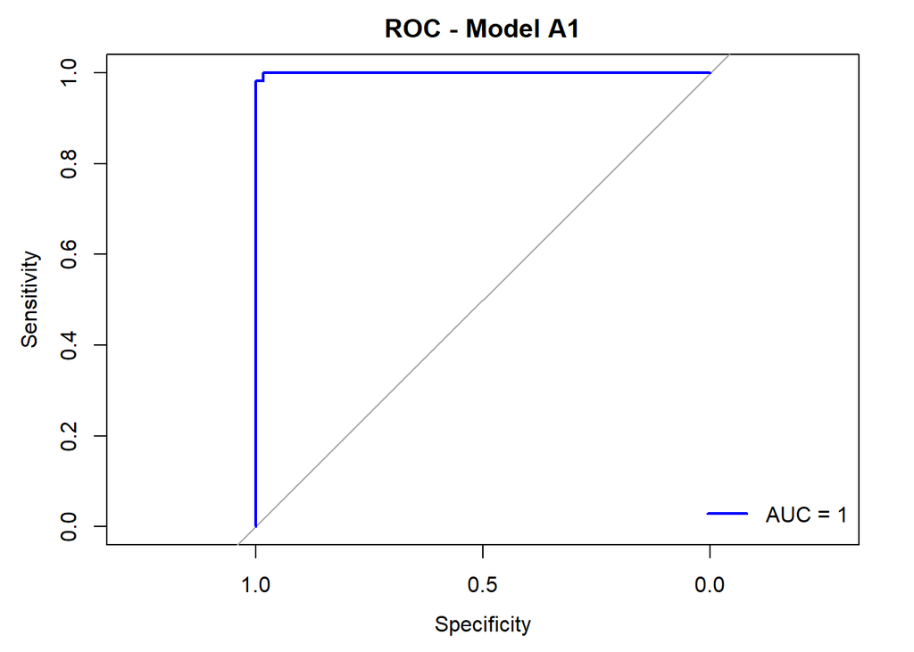

```
## Confusion Matrix and Statistics
##
##           Reference
## Prediction  0  1
##          0 61  1
##          1  0 52
##
##                Accuracy : 0.9912
##                  95% CI : (0.9521, 0.9998)
##     No Information Rate : 0.5351
##     P-Value [Acc > NIR] : <2e-16
##
##                   Kappa : 0.9823
##
##  Mcnemar's Test P-Value : 1
##
##             Sensitivity : 1.0000
##             Specificity : 0.9811
##          Pos Pred Value : 0.9839
##          Neg Pred Value : 1.0000
##              Prevalence : 0.5351
##          Detection Rate : 0.5351
##    Detection Prevalence : 0.5439
##       Balanced Accuracy : 0.9906
##
##        'Positive' Class : 0
##
```

```r
#Model A1: Without tumor_volume (complex)
model_A1 <- glm(formula = diagnosis_bin ~ perimeter_worst + smoothness_worst +
                             texture_worst + radius_se + compactness_mean + symmetry_worst +
                             concave.points_mean + texture_se + concavity_worst + compactness_se,
                family = binomial, data = Cancer_Data_train)

#Model A2: Without tumor_volume (simplified)
model_A2 <- glm(formula = diagnosis_bin ~ perimeter_worst + smoothness_worst +
                             texture_worst + radius_se + concave.points_worst + compactness_mean,
                family = binomial, data = Cancer_Data_train)

#Model B1: With tumor_volume (complex)
model_B1 <- glm(formula = diagnosis_bin ~ tumor_volume + texture_worst +
                             smoothness_worst + symmetry_worst + concave.points_mean +
                             compactness_mean + fractal_dimension_worst,
                family = binomial, data = Cancer_Data_train)

#Model B2: With tumor_volume (simplified)
model_B2 <- glm(formula = diagnosis_bin ~ concave.points_worst + tumor_volume +
                             texture_worst + smoothness_worst,
                family = binomial, data = Cancer_Data_train)


#Define evaluation function
evaluate_model <- function(model, valid_data, model_name = "Model") {
  # redictive probability
  valid_data$predicted_prob <- predict(model, newdata = valid_data, type = "response")

  #Predict classes (threshold = 0.5)
  valid_data$predicted_class <- ifelse(valid_data$predicted_prob >= 0.5 , 1, 0)

  #Pompute ROC and AUC
  roc_obj <- roc(valid_data$diagnosis_bin, valid_data$predicted_prob)
  auc_val <- auc(roc_obj)

  #Plot ROC curve
  plot(roc_obj, col = "blue", main = paste("ROC -", model_name))
  legend("bottomright", legend = paste("AUC =", round(auc_val, 3)),
         col = "blue", lwd = 2, bty = "n")

  #Confusion Matrix
  valid_data$predicted_class <- factor(valid_data$predicted_class, levels = c(0, 1))
  valid_data$diagnosis_bin <- factor(valid_data$diagnosis_bin, levels = c(0, 1))

  conf <- confusionMatrix(valid_data$predicted_class, valid_data$diagnosis_bin)
  print(conf)

  return(auc_val)
}
#Evaluate all models
auc_A1 <- evaluate_model(model_A1, validation_data, "Model A1")
```

```r
auc_A2 <- evaluate_model(model_A2, validation_data, "Model A2")
```

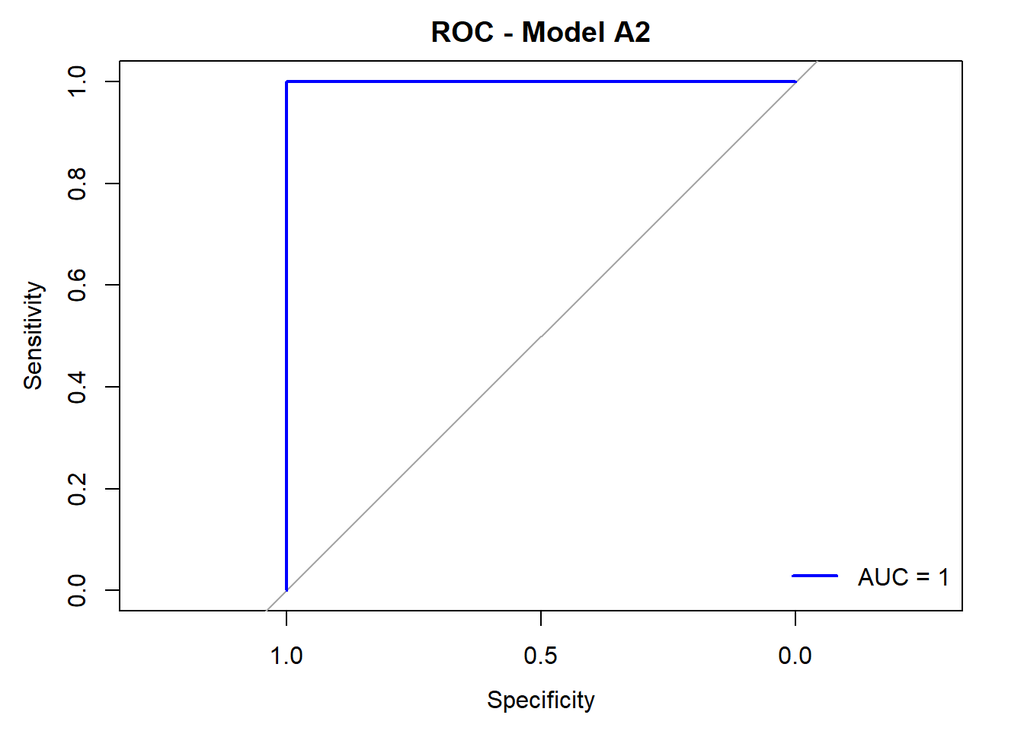

```
## Confusion Matrix and Statistics
##
##           Reference
## Prediction  0  1
##          0 61  0
##          1  0 53
##
##                Accuracy : 1
##                  95% CI : (0.9682, 1)
##     No Information Rate : 0.5351
##     P-Value [Acc > NIR] : < 2.2e-16
##
##                   Kappa : 1
##
##  Mcnemar's Test P-Value : NA
##
##             Sensitivity : 1.0000
##             Specificity : 1.0000
##          Pos Pred Value : 1.0000
##          Neg Pred Value : 1.0000
##              Prevalence : 0.5351
##          Detection Rate : 0.5351
##    Detection Prevalence : 0.5351
##       Balanced Accuracy : 1.0000
##
##        'Positive' Class : 0
##
```

```r
auc_B1 <- evaluate_model(model_B1, validation_data, "Model B1")
```

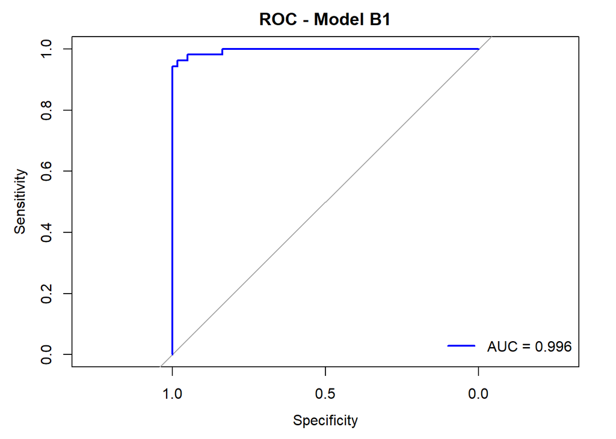

```
## Confusion Matrix and Statistics
##
##           Reference
## Prediction  0  1
##          0 60  2
##          1  1 51
##
##                Accuracy : 0.9737
##                  95% CI : (0.925, 0.9945)
##     No Information Rate : 0.5351
##     P-Value [Acc > NIR] : <2e-16
##
##                   Kappa : 0.947
##
##  Mcnemar's Test P-Value : 1
##
##             Sensitivity : 0.9836
##             Specificity : 0.9623
##          Pos Pred Value : 0.9677
##          Neg Pred Value : 0.9808
##              Prevalence : 0.5351
##          Detection Rate : 0.5263
##    Detection Prevalence : 0.5439
##       Balanced Accuracy : 0.9729
##
##        'Positive' Class : 0
##
```

```r
auc_B2 <- evaluate_model(model_B2, validation_data, "Model B2")
```

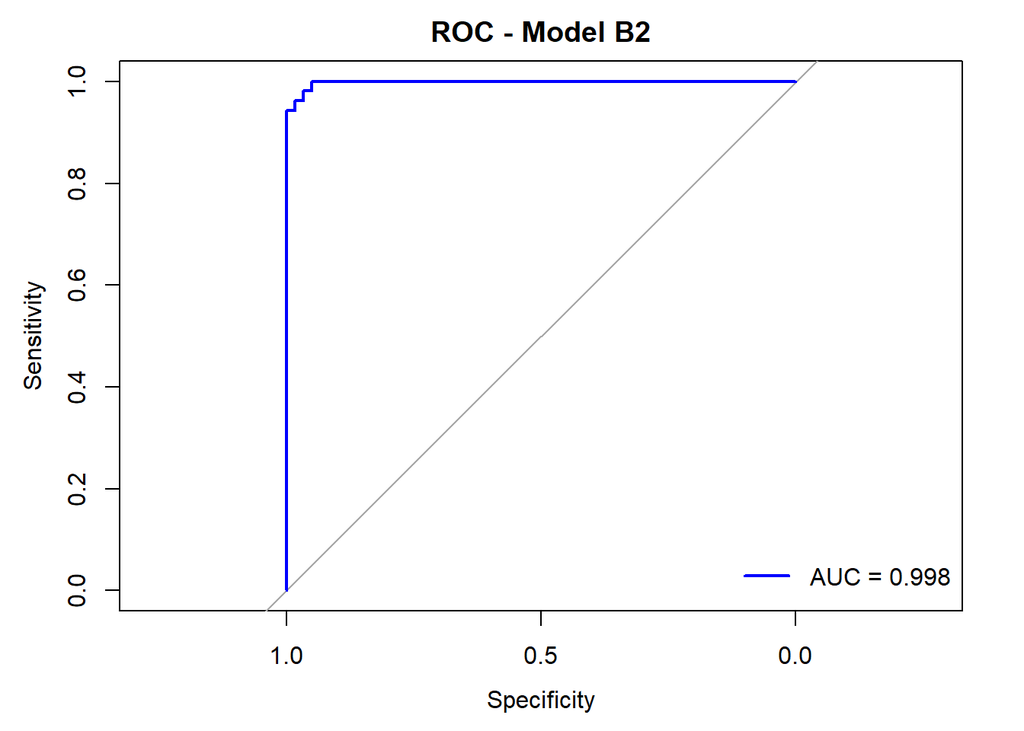

```
## Confusion Matrix and Statistics
##
##           Reference
## Prediction  0  1
##          0 61  3
##          1  0 50
##
##                Accuracy : 0.9737
##                  95% CI : (0.925, 0.9945)
##     No Information Rate : 0.5351
##     P-Value [Acc > NIR] : <2e-16
##
##                   Kappa : 0.9469
##
##  Mcnemar's Test P-Value : 0.2482
##
##             Sensitivity : 1.0000
##             Specificity : 0.9434
##          Pos Pred Value : 0.9531
##          Neg Pred Value : 1.0000
##              Prevalence : 0.5351
##          Detection Rate : 0.5351
##    Detection Prevalence : 0.5614
##       Balanced Accuracy : 0.9717
##
##        'Positive' Class : 0
##
```

## Likelihood Ratio Test: B2 vs. Tumor Volume Only

```r
#Compare nested models (B2 vs. tumor_volume only) using likelihood ratio test
model_small <- glm(diagnosis_bin ~ tumor_volume, data = Cancer_Data_train, family = binomial)
anova(model_small, model_B2, test = "Chisq")
```

```
## Analysis of Deviance Table
##
## Model 1: diagnosis_bin ~ tumor_volume
## Model 2: diagnosis_bin ~ concave.points_worst + tumor_volume + texture_worst +
##     smoothness_worst
##   Resid. Df Resid. Dev Df Deviance  Pr(>Chi)
## 1       453    255.300
## 2       450     95.742  3   159.56 < 2.2e-16 ***
## ---
## Signif. codes:  0 '***' 0.001 '**' 0.01 '*' 0.05 '.' 0.1 ' ' 1
```

Adding `concave.points_worst`, `texture_worst`, and `smoothness_worst` significantly improved the model fit compared to using `tumor_volume` alone. Based on the likelihood ratio test, the full model (B2) provides a better fit and should be preferred.

$$\log\left(\frac{\Pr(\text{diagnosis_bin} = 1)}{\Pr(\text{diagnosis_bin}
= 0)}\right)
= \beta_0
+ \beta_1 \cdot \text{concave.points_worst}
+ \beta_2 \cdot \text{tumor_volume}
+ \beta_3 \cdot \text{texture_worst}
+ \beta_4 \cdot \text{smoothness_worst}$$

## kNN Classification

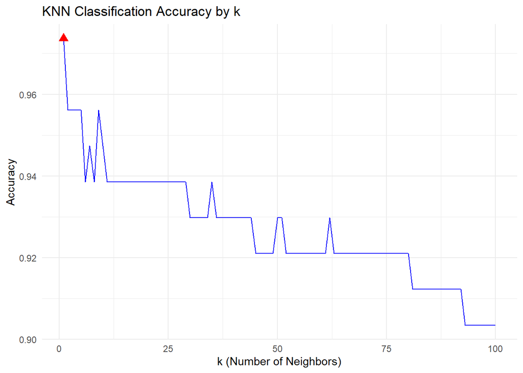

```r
#Define predictor variables
xvars <- c(
  "radius_mean", "texture_mean", "perimeter_mean", "area_mean", "smoothness_mean",
  "compactness_mean", "concavity_mean", "concave.points_mean", "symmetry_mean", "fractal_dimension_mean",
  "radius_se", "texture_se", "perimeter_se", "area_se", "smoothness_se",
  "compactness_se", "concavity_se", "concave.points_se", "symmetry_se", "fractal_dimension_se",
  "radius_worst", "texture_worst", "perimeter_worst", "area_worst", "smoothness_worst",
  "compactness_worst", "concavity_worst", "concave.points_worst", "symmetry_worst", "fractal_dimension_worst","tumor_volume"
)


#KNN tuning: search k from 1 to 100 and record accuracy
k_values <- 1:100
accuracy_values <- numeric(length(k_values))

for (i in seq_along(k_values)) {
  knn_res <- knn(train = Cancer_Data_train[, xvars, drop = FALSE],
                 test = validation_data[, xvars, drop = FALSE],
                 cl = Cancer_Data_train$diagnosis,
                 k = k_values[i])

  accuracy_values[i] <- mean(knn_res == validation_data$diagnosis)
}

#Find optimal k with highest validation accuracy
accuracy_df <- data.frame(k = k_values, accuracy = accuracy_values)
best_k <- accuracy_df$k[which.max(accuracy_df$accuracy)]
best_accuracy <- max(accuracy_df$accuracy)

#Plot accuracy vs. k
ggplot(accuracy_df, aes(x = k, y = accuracy)) +
  geom_line(color = "blue") +
  geom_point(aes(x = best_k, y = best_accuracy), color = "red", shape = 17, size = 3) +
  labs(title = "KNN Classification Accuracy by k",
       x = "k (Number of Neighbors)",
       y = "Accuracy") +
  theme_minimal()
```

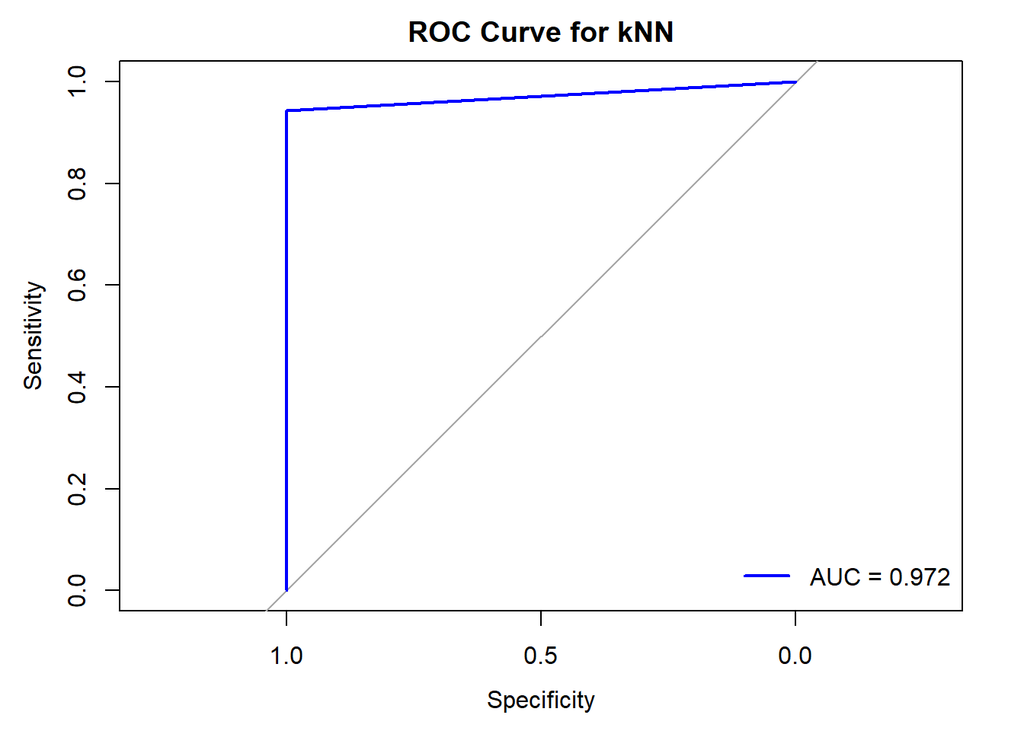

```r
#Final prediction using best k
final_knn <- knn(train = Cancer_Data_train[, xvars, drop = FALSE],
                 test = validation_data[, xvars, drop = FALSE],
                 cl = Cancer_Data_train$diagnosis,
                 k = best_k,
                 prob = TRUE)

#Save predictions
validation_data$pred_diagnosis <- final_knn

#Save probability of "M" (malignant)
#If prediction is "B", prob attribute is for "B" → so we flip it
validation_data$prob_M <- ifelse(final_knn == "M", attr(final_knn, "prob"), 1 - attr(final_knn, "prob"))

roc_curve <- roc(response = validation_data$diagnosis,
                 predictor = validation_data$prob_M,
                 levels = c("B", "M"),  # Specify levels for correct direction
                 direction = "<")

auc_value <- auc(roc_curve)

plot(roc_curve, col = "blue", main = "ROC Curve for kNN")
  legend("bottomright", legend = paste("AUC =", round(auc_value, 3)),
         col = "blue", lwd = 2, bty = "n")
```

```r
#Print best k and accuracy
cat("Best k value:", best_k, "\n")
```

```
## Best k value: 1
```

```r
cat("Validation Accuracy:", round(best_accuracy, 3), "\n")
```

```
## Validation Accuracy: 0.974
```

```r
#Evaluate KNN performance
true_labels <- factor(validation_data$diagnosis, levels = c("B", "M"))
predicted_labels <- factor(validation_data$pred_diagnosis, levels = c("B", "M"))

#Confusion matrix
cm <- confusionMatrix(predicted_labels, true_labels)
print(cm)
```

```
## Confusion Matrix and Statistics
##
##           Reference
## Prediction  B  M
##          B 61  3
##          M  0 50
##
##                Accuracy : 0.9737
##                  95% CI : (0.925, 0.9945)
##     No Information Rate : 0.5351
##     P-Value [Acc > NIR] : <2e-16
##
##                   Kappa : 0.9469
##
##  Mcnemar's Test P-Value : 0.2482
##
##             Sensitivity : 1.0000
##             Specificity : 0.9434
##          Pos Pred Value : 0.9531
##          Neg Pred Value : 1.0000
##              Prevalence : 0.5351
##          Detection Rate : 0.5351
##    Detection Prevalence : 0.5614
##       Balanced Accuracy : 0.9717
##
##        'Positive' Class : B
##
```

```r
#Print best k and accuracy
cat("Best k value:", best_k, "\n")
```

```
## Best k value: 1
```

```r
cat("Validation Accuracy:", round(best_accuracy, 3), "\n")
```

```
## Validation Accuracy: 0.974
```

```r
#Ensure predicted and true labels are factors with the same levels
true_labels <- factor(validation_data$diagnosis, levels = c("B", "M"))
predicted_labels <- factor(final_knn, levels = c("B", "M"))

#Generate confusion matrix
cm <- confusionMatrix(data = predicted_labels, reference = true_labels)
print(cm)
```

```
## Confusion Matrix and Statistics
##
##           Reference
## Prediction  B  M
##          B 61  3
##          M  0 50
##
##                Accuracy : 0.9737
##                  95% CI : (0.925, 0.9945)
##     No Information Rate : 0.5351
##     P-Value [Acc > NIR] : <2e-16
##
##                   Kappa : 0.9469
##
##  Mcnemar's Test P-Value : 0.2482
##
##             Sensitivity : 1.0000
##             Specificity : 0.9434
##          Pos Pred Value : 0.9531
##          Neg Pred Value : 1.0000
##              Prevalence : 0.5351
##          Detection Rate : 0.5351
##    Detection Prevalence : 0.5614
##       Balanced Accuracy : 0.9717
##
##        'Positive' Class : B
##
```

## KNN Classification (Simplified Model)

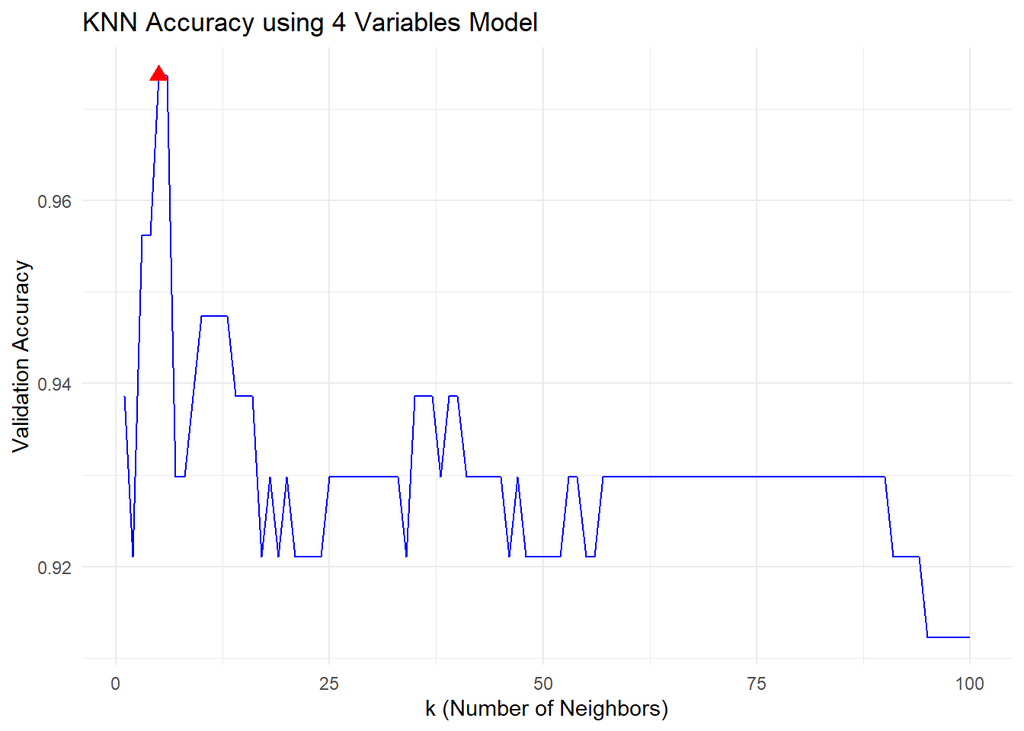

```r
#Define simplified predictor set for KNN
xvars_S <- c("tumor_volume","concave.points_worst" , "texture_worst" , "smoothness_worst")

#Loop over a range of k values to evaluate accuracy
k_values <- 1:100
accuracy_values <- numeric(length(k_values))

for (i in seq_along(k_values)) {
  knn_res <- knn(train = Cancer_Data_train[, xvars_S, drop = FALSE],
                 test  = validation_data[, xvars_S, drop = FALSE],
                 cl    = Cancer_Data_train$diagnosis,
                 k     = k_values[i],
                 prob = TRUE)

  accuracy_values[i] <- mean(knn_res == validation_data$diagnosis)
}

#Identify the best k value based on maximum accuracy
accuracy_df <- data.frame(k = k_values, accuracy = accuracy_values)
best_k <- accuracy_df$k[which.max(accuracy_df$accuracy)]
best_accuracy <- max(accuracy_df$accuracy)

#Visualize how accuracy changes with k
ggplot(accuracy_df, aes(x = k, y = accuracy)) +
  geom_line(color = "blue") +
  geom_point(aes(x = best_k, y = best_accuracy), color = "red", shape = 17, size = 3) +
  labs(title = "KNN Accuracy using 4 Variables Model",
       x = "k (Number of Neighbors)", y = "Validation Accuracy") +
  theme_minimal()
```

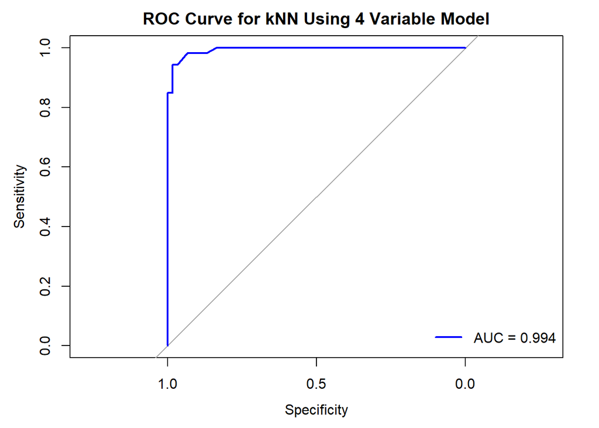

```r
#Save probability of "M" (malignant)
#If prediction is "B", prob attribute is for "B" → so we flip it
validation_data$prob_M <- ifelse(knn_res == "M", attr(knn_res, "prob"), 1 - attr(knn_res, "prob"))

#Plot ROC and compute AUC
roc_curve <- roc(response = validation_data$diagnosis,
                 predictor = validation_data$prob_M,
                 levels = c("B", "M"),  # Specify levels for correct direction
                 direction = "<")

auc_value <- auc(roc_curve)

plot(roc_curve, col = "blue", main = "ROC Curve for kNN Using 4 Variable Model")
  legend("bottomright", legend = paste("AUC =", round(auc_value, 3)),
         col = "blue", lwd = 2, bty = "n")
```

```r
cat("Best k using 4 variables:", best_k, "\n")
```

```
## Best k using 4 variables: 5
```

```r
cat("Validation Accuracy:", round(best_accuracy, 3), "\n")
```

```
## Validation Accuracy: 0.974
```

```r
#Confusion matrix
true_labels <- factor(validation_data$diagnosis, levels = c("B", "M"))
predicted_labels <- factor(knn_res, levels = c("B", "M"))
cm <- confusionMatrix(data = predicted_labels, reference = true_labels)
print(cm)
```

```
## Confusion Matrix and Statistics
##
##           Reference
## Prediction  B  M
##          B 61 10
##          M  0 43
##
##                Accuracy : 0.9123
##                  95% CI : (0.8446, 0.9571)
##     No Information Rate : 0.5351
##     P-Value [Acc > NIR] : < 2.2e-16
##
##                   Kappa : 0.8215
##
##  Mcnemar's Test P-Value : 0.004427
##
##             Sensitivity : 1.0000
##             Specificity : 0.8113
##          Pos Pred Value : 0.8592
##          Neg Pred Value : 1.0000
##              Prevalence : 0.5351
##          Detection Rate : 0.5351
##    Detection Prevalence : 0.6228
##       Balanced Accuracy : 0.9057
##
##        'Positive' Class : B
##
```

## Multilevel Model

### Research Question for Multilevel Modeling

This multilevel modeling part explores the following research question:

**Does the predictive power of tumor-related features vary across latent population structures in breast cancer diagnosis?**

If such heterogeneity exists, can we identify these structural groupings through techniques like PCA or K-means clustering, and account for them using mixed-effects modeling?

Multilevel modeling is introduced here to address inter-group variability that traditional models cannot capture, allowing us to assess whether such structure has statistical explanatory power.

## PCA

To explore potential structural groupings, we begin with dimensionality reduction via Principal Component Analysis (PCA).

```r
#Select relevant variables, excluding ID, diagnosis, and Hospital
vars <- setdiff(names(Cancer_Data_train), c("id", "diagnosis", "diagnosis_bin", "predicted_prob","Hospital",
  "radius_mean", "perimeter_mean", "area_mean",
  "radius_se", "perimeter_se", "area_se",
  "radius_worst", "perimeter_worst", "area_worst"))

#Filter data and remove rows with missing values
cancer_filtered <- Cancer_Data_train %>%
  dplyr::select(all_of(vars)) %>%
  filter(if_all(everything(), ~ !is.na(.))) %>%
  mutate(across(everything(), as.numeric))

#Perform PCA on the standardized data
pca_model <- prcomp(cancer_filtered, scale. = TRUE)

#Print PCA loadings
loadings <- pca_model$rotation
print("~~PCA Loadings~~")
```

```
## [1] "~~PCA Loadings~~"
```

```r
print(round(loadings, 3))
```

```
##                            PC1    PC2    PC3    PC4    PC5    PC6    PC7    PC8
## texture_mean            -0.107  0.209  0.328 -0.436 -0.173  0.083  0.036 -0.064
## smoothness_mean         -0.206 -0.089 -0.269 -0.112  0.343  0.278 -0.111  0.240
## compactness_mean        -0.309  0.038 -0.051  0.056  0.031  0.023 -0.264 -0.060
## concavity_mean          -0.296  0.125  0.104  0.143  0.087  0.018 -0.005  0.008
## concave.points_mean     -0.262  0.227  0.075  0.113  0.278  0.053 -0.179 -0.013
## symmetry_mean           -0.196 -0.107 -0.151 -0.187  0.239 -0.380 -0.048  0.417
## fractal_dimension_mean  -0.187 -0.348 -0.207 -0.071 -0.164  0.135 -0.295  0.049
## texture_se              -0.065 -0.193  0.389 -0.381  0.125  0.072 -0.248  0.251
## smoothness_se           -0.078 -0.353  0.099 -0.105  0.288  0.356  0.385 -0.421
## compactness_se          -0.255 -0.194  0.186  0.140 -0.179 -0.074 -0.033 -0.196
## concavity_se            -0.223 -0.169  0.230  0.227 -0.172 -0.062  0.400  0.237
## concave.points_se       -0.231 -0.112  0.266  0.218  0.091 -0.001  0.246  0.331
## symmetry_se             -0.092 -0.313  0.127 -0.164  0.283 -0.447 -0.005 -0.392
## fractal_dimension_se    -0.198 -0.333  0.145  0.133 -0.201  0.042 -0.231 -0.025
## texture_worst           -0.116  0.244  0.226 -0.500 -0.214  0.091  0.069  0.041
## smoothness_worst        -0.195  0.010 -0.356 -0.202  0.134  0.356  0.303 -0.018
## compactness_worst       -0.282  0.124 -0.135 -0.002 -0.233 -0.054 -0.038 -0.213
## concavity_worst         -0.285  0.163 -0.030  0.084 -0.186 -0.028  0.237  0.001
## concave.points_worst    -0.267  0.273 -0.032  0.098  0.080  0.011  0.089  0.053
## symmetry_worst          -0.176  0.056 -0.280 -0.250  0.021 -0.511  0.231 -0.106
## fractal_dimension_worst -0.243 -0.092 -0.252 -0.068 -0.356  0.074 -0.175 -0.125
## tumor_volume            -0.148  0.331  0.199  0.166  0.328  0.014 -0.252 -0.286
##                            PC9   PC10   PC11   PC12   PC13   PC14   PC15   PC16
## texture_mean            -0.261  0.185  0.421  0.159 -0.058 -0.086 -0.137 -0.046
## smoothness_mean          0.229  0.107  0.277  0.232  0.337 -0.052 -0.236 -0.426
## compactness_mean        -0.042  0.209 -0.036  0.298 -0.023  0.070  0.314  0.021
## concavity_mean           0.042 -0.319  0.092  0.164 -0.163 -0.219  0.234  0.013
## concave.points_mean     -0.016 -0.005  0.030 -0.094 -0.111 -0.282  0.290 -0.079
## symmetry_mean           -0.600 -0.129 -0.150  0.136 -0.008 -0.049 -0.187  0.219
## fractal_dimension_mean   0.006 -0.030  0.253  0.003 -0.461  0.380  0.240  0.108
## texture_se               0.365 -0.205 -0.504 -0.075 -0.024  0.045  0.007 -0.052
## smoothness_se           -0.351 -0.073 -0.211  0.017 -0.204 -0.050  0.041 -0.265
## compactness_se          -0.090  0.236 -0.218  0.226  0.438  0.161  0.144  0.096
## concavity_se             0.122 -0.360  0.228  0.136  0.087  0.263  0.016 -0.045
## concave.points_se        0.028  0.546  0.002 -0.261 -0.210  0.157 -0.185 -0.049
## symmetry_se              0.368  0.109  0.260  0.070 -0.096 -0.174 -0.188  0.303
## fractal_dimension_se    -0.184 -0.134  0.185 -0.460  0.389 -0.361  0.029  0.000
## texture_worst            0.002 -0.003  0.053 -0.102  0.092  0.086  0.149  0.053
## smoothness_worst         0.110 -0.039 -0.005 -0.170  0.252  0.092  0.055  0.577
```

[output cut: 14 more lines]

```
## texture_se               0.120 -0.011 -0.139  0.196 -0.056  0.017
## smoothness_se           -0.041 -0.107  0.096 -0.028 -0.028  0.002
## compactness_se          -0.435  0.305 -0.212  0.041 -0.153  0.069
## concavity_se             0.079  0.038  0.397  0.299 -0.004 -0.136
## concave.points_se        0.176  0.095 -0.167 -0.297  0.100 -0.012
## symmetry_se             -0.032 -0.005  0.160 -0.054  0.019 -0.018
## fractal_dimension_se     0.144 -0.310 -0.062 -0.063  0.096 -0.017
## texture_worst           -0.265 -0.056  0.388 -0.529  0.079 -0.040
## smoothness_worst         0.231  0.150 -0.152  0.062  0.031 -0.051
## compactness_worst        0.186 -0.214  0.135  0.135  0.652 -0.009
## concavity_worst         -0.159 -0.308 -0.426 -0.239 -0.230 -0.305
## concave.points_worst    -0.359 -0.324  0.227  0.414 -0.215  0.312
## symmetry_worst           0.102  0.017 -0.224  0.030 -0.047  0.018
## fractal_dimension_worst  0.047  0.488  0.218 -0.011 -0.264  0.044
## tumor_volume             0.001 -0.093 -0.075 -0.060 -0.031  0.005
```

```r
#Print proportion of variance explained by each principal component
explained_var <- summary(pca_model)$importance
print("~~Proportion of variance explained by each PC~~")
```

```
## [1] "~~Proportion of variance explained by each PC~~"
```

```r
print(round(explained_var, 3))
```

```
##                          PC1   PC2   PC3   PC4   PC5   PC6   PC7   PC8   PC9
## Standard deviation     3.050 1.799 1.535 1.357 1.213 1.115 0.693 0.679 0.580
## Proportion of Variance 0.423 0.147 0.107 0.084 0.067 0.056 0.022 0.021 0.015
## Cumulative Proportion  0.423 0.570 0.677 0.761 0.828 0.884 0.906 0.927 0.942
##                         PC10  PC11  PC12  PC13  PC14  PC15  PC16  PC17  PC18
## Standard deviation     0.545 0.507 0.459 0.376 0.295 0.286 0.236 0.191 0.174
## Proportion of Variance 0.014 0.012 0.010 0.006 0.004 0.004 0.003 0.002 0.001
## Cumulative Proportion  0.956 0.967 0.977 0.983 0.987 0.991 0.994 0.995 0.997
##                         PC19  PC20  PC21  PC22
## Standard deviation     0.162 0.154 0.127 0.094
## Proportion of Variance 0.001 0.001 0.001 0.000
## Cumulative Proportion  0.998 0.999 1.000 1.000
```

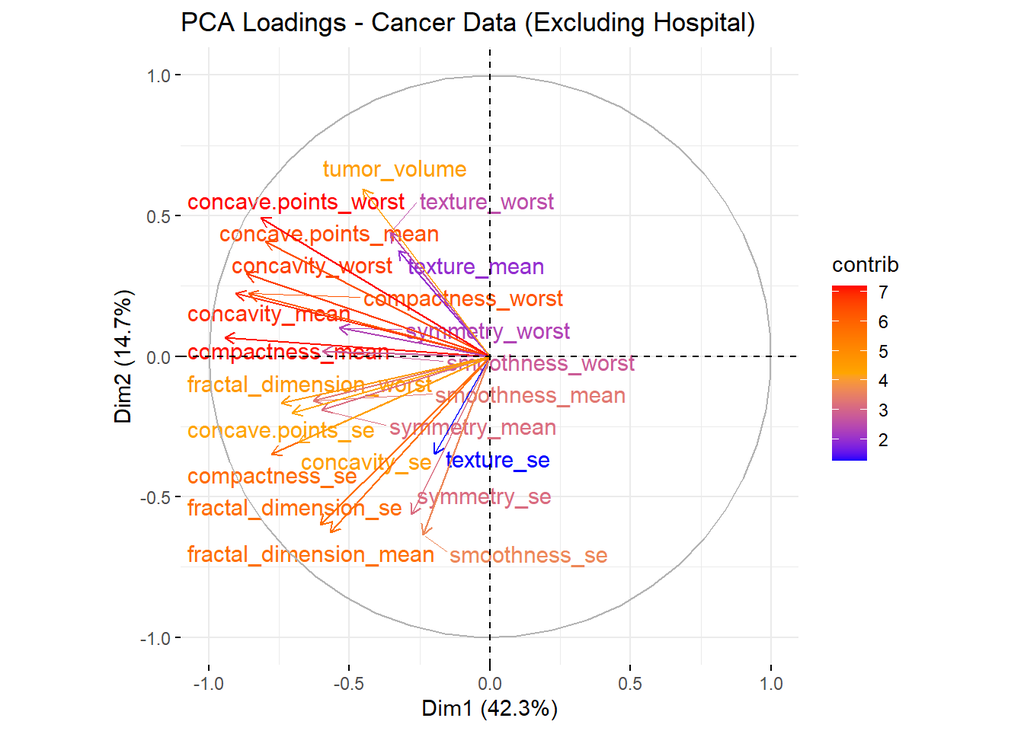

```r
#Visualize variable contributions to principal components
fviz_pca_var(pca_model,
             col.var = "contrib",
             gradient.cols = c("blue", "orange", "red"),
             repel = TRUE) +
  ggtitle("PCA Loadings - Cancer Data (Excluding Hospital)")
```

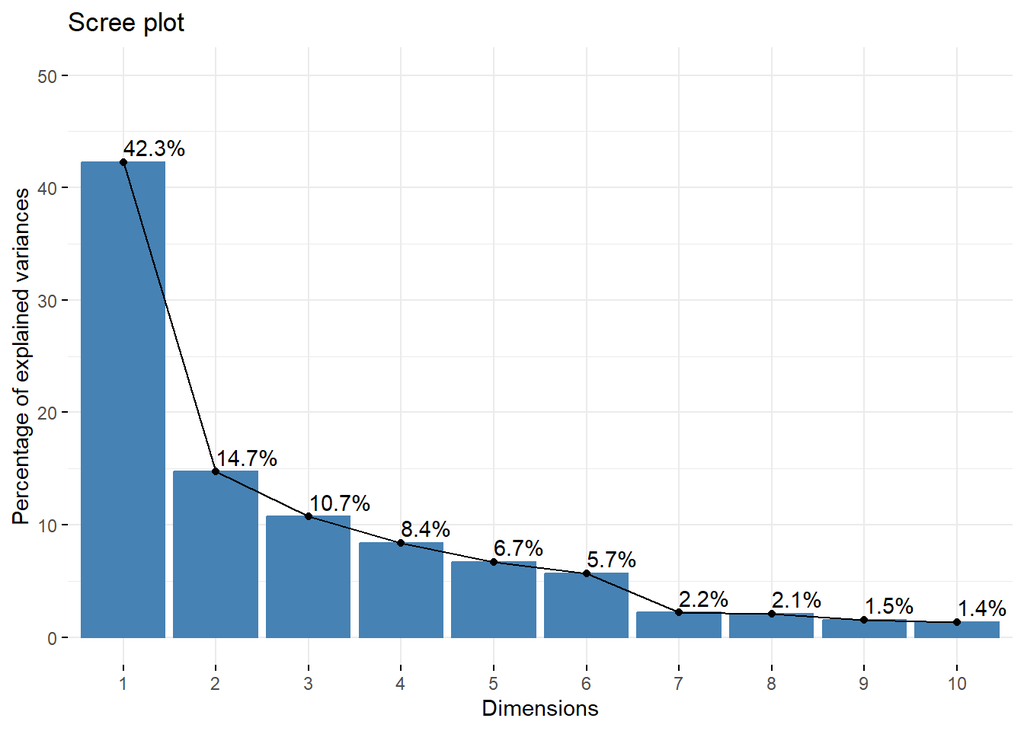

```r
#Visualize samples colored by cos2
fviz_screeplot(pca_model, addlabels = TRUE, ylim = c(0, 50))
```

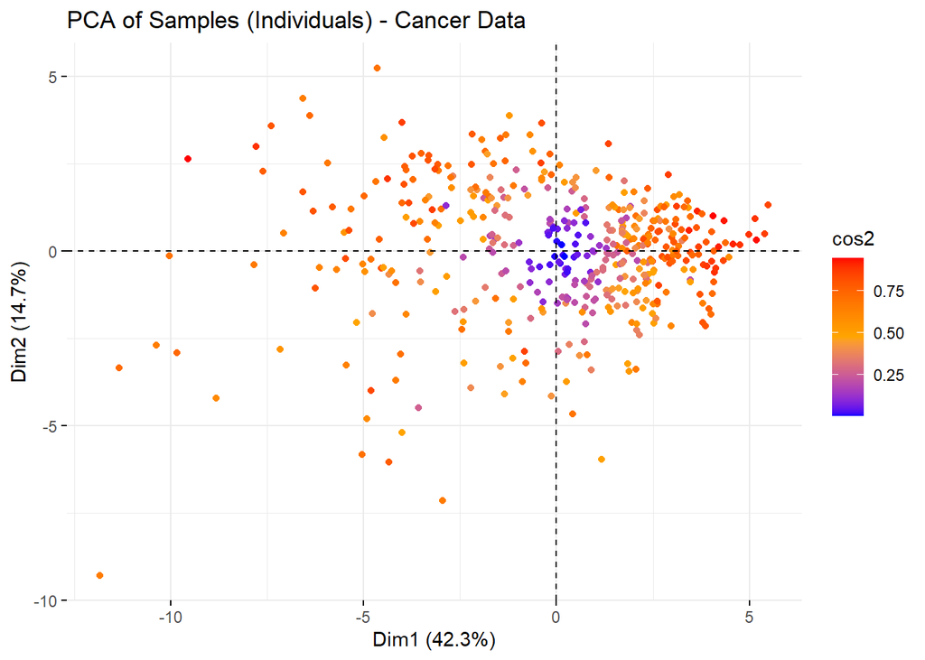

```r
fviz_pca_ind(pca_model,
             geom.ind = "point",
             col.ind = "cos2",
             gradient.cols = c("blue", "orange", "red"),
             repel = TRUE) +
  ggtitle("PCA of Samples (Individuals) - Cancer Data")
```

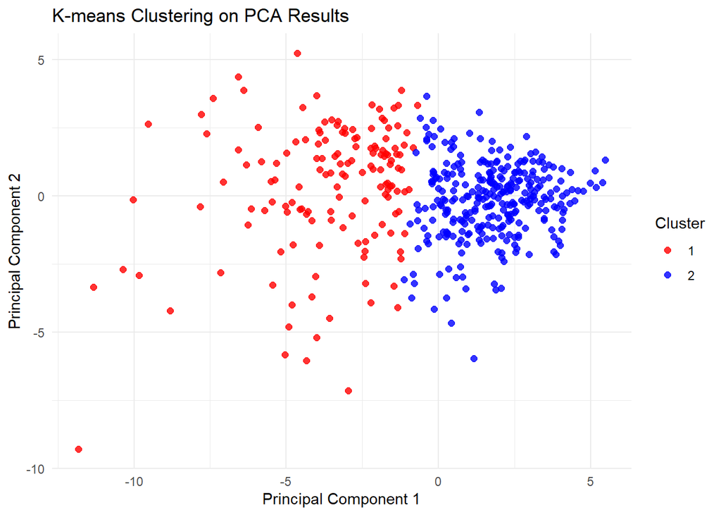

```r
#Extract PC1 and PC2 scores
pca_scores <- as.data.frame(pca_model$x[, 1:2])
colnames(pca_scores) <- c("PC1", "PC2")

#Apply k-means clustering (2 clusters)
set.seed(123)
kmeans_result <- kmeans(pca_scores, centers = 2, nstart = 25)

#Add cluster labels to PCA scores
pca_scores$Cluster <- as.factor(kmeans_result$cluster)

#Visualize clusters on PC1-PC2 plot
ggplot(pca_scores, aes(x = PC1, y = PC2, color = Cluster)) +
  geom_point(size = 2, alpha = 0.8) +
  labs(title = "K-means Clustering on PCA Results",
       x = "Principal Component 1",
       y = "Principal Component 2") +
  theme_minimal() +
  scale_color_manual(values = c("red", "blue"))
```

```r
#Extract loading matrix from PCA result
loadings_matrix <- pca_model$rotation

#Initialize an empty list to store top contributing variables for each PC
top_variables_list <- list()

#Get top 10 contributing variables for each of the first 7 PCs
for (i in 1:7) {
  pc_loadings <- loadings_matrix[, i]
  top_vars <- sort(abs(pc_loadings), decreasing = TRUE)[1:10]
  top_variables_list[[paste0("PC", i)]] <- names(top_vars)
}

#Display the top variables for each of the first 7 PCs
top_variables_list
```

```
## $PC1
##  [1] "compactness_mean"        "concavity_mean"
##  [3] "concavity_worst"         "compactness_worst"
##  [5] "concave.points_worst"    "concave.points_mean"
##  [7] "compactness_se"          "fractal_dimension_worst"
##  [9] "concave.points_se"       "concavity_se"
##
## $PC2
##  [1] "smoothness_se"          "fractal_dimension_mean" "fractal_dimension_se"
##  [4] "tumor_volume"           "symmetry_se"            "concave.points_worst"
##  [7] "texture_worst"          "concave.points_mean"    "texture_mean"
## [10] "compactness_se"
##
## $PC3
##  [1] "texture_se"              "smoothness_worst"
```

[output cut: 30 more lines]

## PCA Grouping Based on PC1 and PC2 Scores

```r
#Add cluster group from k-means result
pca_scores$cluster_group <- as.factor(kmeans_result$cluster)

#Group PC1 into tertiles: Low, Medium, High
pca_scores$pc1_group <- cut(pca_scores$PC1,
                            breaks = quantile(pca_scores$PC1, probs = c(0, 0.33, 0.66, 1)),
                            labels = c("Low", "Medium", "High"),
                            include.lowest = TRUE)


#Bin PC1 and PC2 separately into two levels: Low and High
pca_scores$pc1_bin <- cut(pca_scores$PC1, breaks=2, labels=c("Low", "High"))
pca_scores$pc2_bin <- cut(pca_scores$PC2, breaks=2, labels=c("Low", "High"))

#Combine PC1 and PC2 binary groups
pca_scores$pca_group <- interaction(pca_scores$pc1_bin, pca_scores$pc2_bin)

#Add PCA group and cluster group as grouping variables
pca_scores$diagnosis_bin <- Cancer_Data_train$diagnosis_bin
pca_scores$tumor_volume <- Cancer_Data_train$tumor_volume
pca_scores$concave.points_worst <- Cancer_Data_train$concave.points_worst
pca_scores$texture_worst <- Cancer_Data_train$texture_worst
pca_scores$smoothness_worst <- Cancer_Data_train$smoothness_worst

#Variables used in modeling
tumor_shape_vars <- c("concave.points_mean", "concave.points_worst",
                      "concavity_mean", "concavity_worst")


#Multilevel model with PCA group as random intercept
model1 <- glmer(diagnosis_bin ~ tumor_volume + (1 | pca_group),
               data = pca_scores,
               family = binomial)

#Multilevel model with cluster group as random intercept
model2 <- glmer(diagnosis_bin ~ tumor_volume + (1 | cluster_group),
               data = pca_scores,
               family = binomial)

#View summaries and random effects
summary(model1)
```

```
## Generalized linear mixed model fit by maximum likelihood (Laplace
##   Approximation) [glmerMod]
##  Family: binomial  ( logit )
## Formula: diagnosis_bin ~ tumor_volume + (1 | pca_group)
##    Data: pca_scores
##
##      AIC      BIC   logLik deviance df.resid
##    205.5    217.8    -99.7    199.5      452
##
## Scaled residuals:
##     Min      1Q  Median      3Q     Max
## -2.6787 -0.2510 -0.1233  0.0125  7.6064
##
## Random effects:
##  Groups    Name        Variance Std.Dev.
##  pca_group (Intercept) 7.833    2.799
## Number of obs: 455, groups:  pca_group, 4
##
## Fixed effects:
##              Estimate Std. Error z value Pr(>|z|)
## (Intercept)    0.7335     1.5173   0.483    0.629
## tumor_volume   5.3175     0.6306   8.432   <2e-16 ***
## ---
## Signif. codes:  0 '***' 0.001 '**' 0.01 '*' 0.05 '.' 0.1 ' ' 1
##
## Correlation of Fixed Effects:
##             (Intr)
## tumor_volum 0.140
```

```r
summary(model2)
```

```
## Generalized linear mixed model fit by maximum likelihood (Laplace
##   Approximation) [glmerMod]
##  Family: binomial  ( logit )
## Formula: diagnosis_bin ~ tumor_volume + (1 | cluster_group)
##    Data: pca_scores
##
##      AIC      BIC   logLik deviance df.resid
##    193.3    205.7    -93.7    187.3      452
##
## Scaled residuals:
##     Min      1Q  Median      3Q     Max
## -3.1041 -0.2069 -0.1025  0.0107  8.0462
##
## Random effects:
##  Groups        Name        Variance Std.Dev.
##  cluster_group (Intercept) 2.733    1.653
## Number of obs: 455, groups:  cluster_group, 2
##
## Fixed effects:
##              Estimate Std. Error z value Pr(>|z|)
## (Intercept)    0.6356     1.1960   0.531    0.595
## tumor_volume   5.2970     0.6381   8.301   <2e-16 ***
## ---
## Signif. codes:  0 '***' 0.001 '**' 0.01 '*' 0.05 '.' 0.1 ' ' 1
##
## Correlation of Fixed Effects:
##             (Intr)
## tumor_volum 0.131
```

```r
ranef(model1)
```

```
## $pca_group
##           (Intercept)
## Low.Low    0.07865043
## High.Low  -2.33311240
## Low.High   3.93507945
## High.High -1.10177175
##
## with conditional variances for "pca_group"
```

```r
ranef(model2)
```

```
## $cluster_group
##   (Intercept)
## 1    1.626580
## 2   -1.615119
##
## with conditional variances for "cluster_group"
```

The effect of `tumor_volume` on malignant diagnoses was highly significant in both models. However, the clustering-based model demonstrated better overall fit (lower AIC and BIC), suggesting that naturally derived structural groupings explain more variation in diagnostic outcomes than manually defined regional bins.

Fixed effects represent overall effects that apply to all observations. Here, the effect of tumor_volume is consistently strong and statistically significant.

Random effects capture variability across latent groupings that are not the main focus but influence the response. These are included to control for unobserved heterogeneity.

Among the PCA-defined groups:

Low.High (small volume, irregular shape/high texture) shows the highest baseline risk,

while High.Low (large volume, smooth shape/low texture) shows the lowest.

Grouping Explanation of possible combinations of features

Low.Low Small volume + Smoothness/weak texture

High.Low large volume + smooth/weak texture

Low.High Small volume + irregular edges/high texture

High.High large volume + irregular edges/high texture

## LASSO Regression

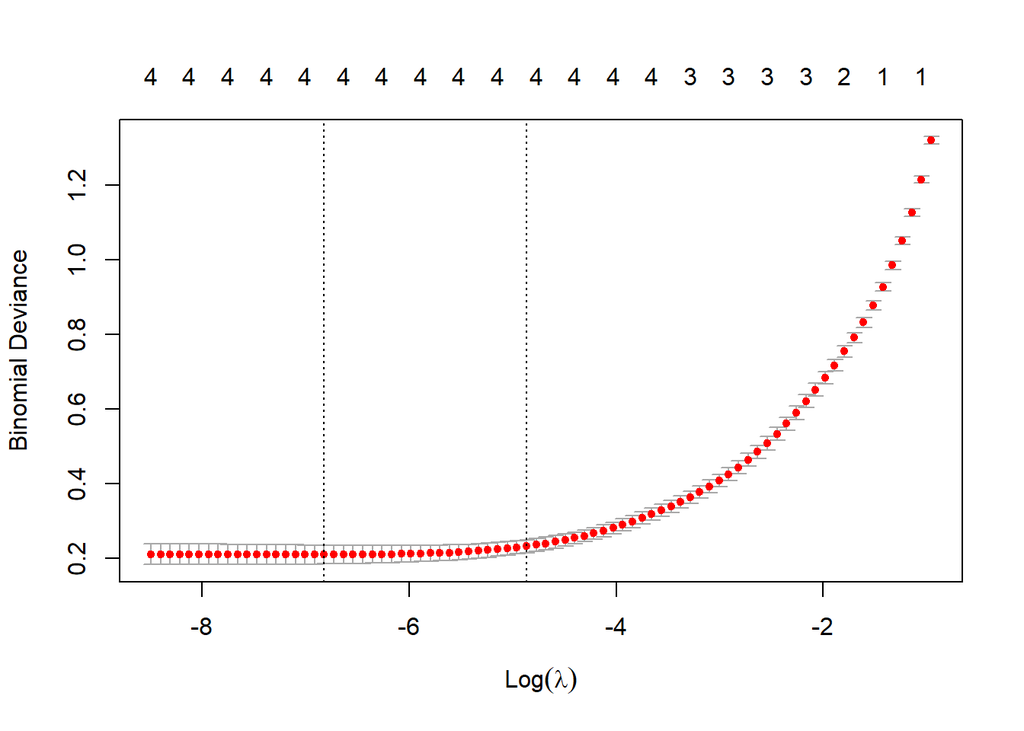

```r
#Prepare data for glmnet
y <- Cancer_Data$diagnosis
X <- as.matrix(Cancer_Data[, xvars_S])

#Fit LASSO logistic regression with cross-validation
set.seed(123)
lasso_fit <- cv.glmnet(X, y, family = "binomial", alpha = 1)

#Plot cross-validation error to find optimal lambda
plot(lasso_fit)
```

```r
#Extract lambda that minimizes CV error
best_lambda <- lasso_fit$lambda.min
cat("Best lambda :", best_lambda)
```

```
## Best lambda : 0.001092744
```

```r
#Get coefficients at optimal lambda
coef(lasso_fit, s = "lambda.min")
```

```
## 5 x 1 sparse Matrix of class "dgCMatrix"
##                              s1
## (Intercept)          -0.3904075
## tumor_volume          5.6589557
## concave.points_worst  2.5958589
## texture_worst         1.6302171
## smoothness_worst      0.9863094
```

The optimal lambda is very small, indicating minimal regularization. This suggests the model behaves almost like a standard logistic regression, so LASSO adds little benefit in this case.

## Random Forest

```r
#Convert diagnosis to factor for classification
Cancer_Data$diagnosis <- as.factor(Cancer_Data$diagnosis)

#Train a Random Forest model with 500 trees and variable importance enabled
set.seed(123)
rf_model <- randomForest(diagnosis ~ radius_mean + texture_mean + perimeter_mean + area_mean + smoothness_mean,
                         data = Cancer_Data,
                         importance = TRUE,
                         ntree = 500)

#View model summary
print(rf_model)
```

```
##
## Call:
##  randomForest(formula = diagnosis ~ radius_mean + texture_mean +      perimeter_mean + area_mean + smoothness_mean, data = Cancer_Data,      importance = TRUE, ntree = 500)
##                Type of random forest: classification
##                      Number of trees: 500
## No. of variables tried at each split: 2
##
##         OOB estimate of  error rate: 7.91%
## Confusion matrix:
##     B   M class.error
## B 340  17  0.04761905
## M  28 184  0.13207547
```

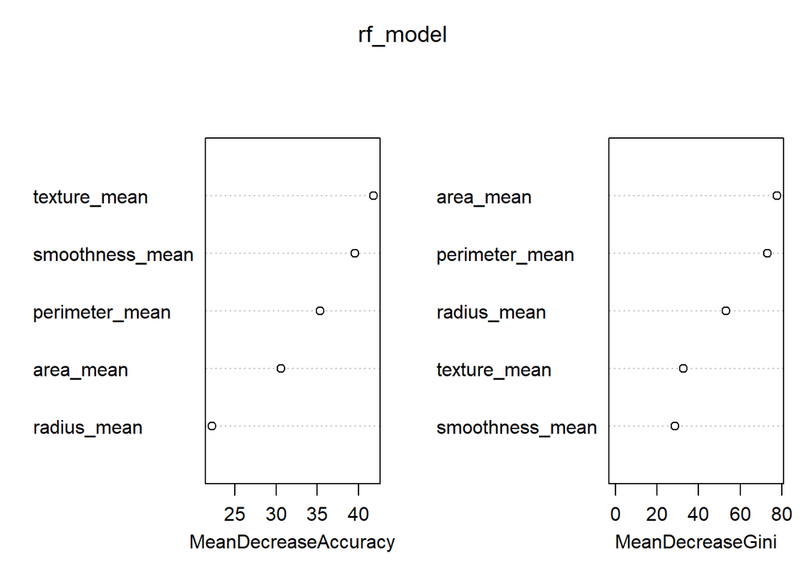

```r
#Variable importance plot
varImpPlot(rf_model)
```

Here, we used a random forest model and obtained an out-of-bag (OOB) error rate of 7.91%, indicating that the model predicts the correct diagnosis approximately 92.1% of the time. Based on the confusion matrix, the model performs better at identifying benign tumors than malignant ones, possibly because benign cases are more prevalent in the dataset.

In the variable importance plot, `texture_mean` shows the highest value, suggesting that prediction accuracy significantly decreases when this feature is randomly permuted. This indicates that `texture_mean` is one of the most influential predictors. In contrast, `radius_mean` has the lowest importance score, implying that the model relies less on this variable when making predictions.

## Conclusions

### Generalized Linear Model (GLM)

Research Question: Is it possible to build a simpler and highly interpretable logistic regression model (GLM) for breast cancer malignancy prediction by constructing more interpretable tumor volume variables?

Conclusion:

The model performed well after the inclusion of the derived variable tumor_volume (AUC = 0.984), which can be considered a strong predictor.

Despite the use of LASSO for variable selection, the optimal λ was small, indicating a limited regularization effect, suggesting that the variable itself had strong predictive power.

The full model (with texture_worst, concave.points_worst, smoothness_worst) showed a significant improvement in fit compared to the tumor_volume-only model (based on the likelihood ratio test)

### Multilevel Model (MLM)

Research Question: Does the predictive power of tumor-related traits vary by underlying population structure (e.g., hospital or implied group)?If such heterogeneity exists, can we identify these structures through PCA or K-means clustering and adjust for them using mixed effects models?

Conclusion:

Two MLM models used PCA grouping (4 groups) and K-means clustering grouping (2 groups) as random intercept grouping variables, respectively.

Both models found tumor_volume to be a significant predictor.

The model using K-means grouping (AIC = 193.3) outperformed the PCA grouping model (AIC = 205.5), suggesting that data-driven hidden structure explains diagnostic heterogeneity better than artificially set groupings.

The first two principal components (PC1 and PC2) explained approximately 57% of the total variance, with PC1 primarily representing tumor shape complexity and PC2 associated with symmetry and volume.

Scores using PC1 and PC2 were divided into two subgroups by K-means clustering, which was subsequently used to good effect for MLM grouping.

Top loading variable analysis revealed that concavity, compactness, concave points, etc. contributed significantly to several principal components.